# Machine learning modelling of nutrition indicators in children under five years in Ghana

Eric Komla Anku and Henry Ofori-Duah

2022-06-11

```r
pacman::p_load(
        tidyverse, # Data wrangling and visualisation
        rio, # Import dataset
        here, # Directory management
        finalfit, # Model parameters and column labelling
        ggstatsplot, # Statistical plots
        GGally, # Scatterplot matrix
        caret, # Machine learning
        gtsummary, # Summary tables
        janitor, # Data cleaning
        parameters, # Model parameters
        naniar ,# Handling missing values
        survey, # Complex Survey Design
        pROC,
        ROCR,
        party,
        randomForest,
        labelled,
        tableone
)
```

```
##
##  C:\Users\LENOVO\AppData\Local\Temp\Rtmp6DBS1o\downloaded_packages
```

# Data wrangling

```r
df <- import(here("data","GHKR72FL.SAV")) # Import data set from the data folder
```

## Variable selection

- Divide the z-score variables by 100

#### Outcome variables

- WFH z-scores (HW72); 9996: height out of plausible limit, 9997: Age in days out of plausible limit, 9998: Flagged cases
- HFA z-scores (HW70); 9996: height out of plausible limit, 9997: Age in days out of plausible limit, 9998: Flagged cases
- WFA z-scores (HW71); 9996: height out of plausible limit, 9997: Age in days out of plausible limit, 9998: Flagged cases

#### Features

- Type of place of residence (V102): 1 for Urban, 2 for Rural
- child age in months (HW1)
- Birth order number (B0RD)
- Gender of the child (B4): 1 for Male, 2 for female
- Birth weight in kg (M19): 9996: No weight; 9998: Don’t know; Divide by 1000
- Number of children 5 and under in household (V137)
- Highest education level (v106): 0 for No education, 1 for Primary, 2 for Secondary, 3 for Higher
- Wealth index (V190): 1 for Poorest, 2 for Poorer, 3 for Middle, 4 for Richer, 5 for Richest
- Had diarrhea recently (H11): 0 for No, 1 for Yes, last 24 hours, 2 for Yes, last two weeks, 8 for don’t know (Join the values for yes into one)
- Type of toilet facility ();
- Weight in kg (HW2): 9994 for present, 9995 for Refused, 9996 for other; Divide weight by 10.
- Region (V024): 1 for Western, 2 for Central, 3 for Greater Accra, 4 for Volta, 5 for Eastern, 5 for Ashanti, 7 for Brong Ahafo, 8 for Nothern, 9 for Upper East, 10 for Upper West
- Source of drinking water (V113): 10 for Piped water, 20 for Tube well water, 32 for Unprotected well, 43 for River, 71 for Bottled water, 11 for Piped into dwelling, 21 for Tube well or borehole, 40 for Surface Water, 51 for rain water, 72 for Sachet water, 12 for Piped to yard/plot, 30 for Dug well, 41 for Protected spring, 61 for Tanker trunk, 96 for other, 13 for public tap/standpipe, 31 for protected well, 42 for unprotected spring, 62 for cart with small tank, and 97 for not a dejure resident ; Recode to improved and non-improved sources of water

The improved water source included all forms of Pipe Water, Borehole, Protected Well/Spring, and Sachet/Bottle water. The unimproved water source included Open River, Dam/stream, and unprotected well/spring.

```r
# Use select() function from tidyverse to select columns of interest
child <- df%>%
        select(HW72, #WFH z-scores
               HW70, # HFA z-scores
               HW71, # WFA z-scores
               V102, # Type of place of residence
               HW1, # Child age in months
               BORD, # Birth order number
               B4, # Gender of child
               M19, # Birth weight of child
               V137, # Number of children 5 and under
               V106, # Highest education level
               V190, # Wealth index
               H11, # Had diarrhoea recently
               HW2, # Weight of child
               V024, # Region
               V113, # Source of drinking water
               V005,# Sample Weight
               V021,# PSU
               V023,# Strata
        )
```

```r
dim <- dim(child) # Dimensions of dataset
```

```r
ff_glimpse(child) #Overview of dataset including missing data
```

```
## $Continuous
##                                                      label var_type    n
## HW72            Weight/Height standard deviation (new WHO)    <dbl> 2738
## HW70               Height/Age standard deviation (new WHO)    <dbl> 2738
## HW71               Weight/Age standard deviation (new WHO)    <dbl> 2738
## V102                            Type of place of residence    <dbl> 5884
## HW1                                  Child's age in months    <dbl> 2782
## BORD                                    Birth order number    <dbl> 5884
## B4                                            Sex of child    <dbl> 5884
## M19                 Birth weight in kilograms (3 decimals)    <dbl> 5881
## V137 Number of children 5 and under in household (de jure)    <dbl> 5884
## V106                             Highest educational level    <dbl> 5884
## V190                                          Wealth index    <dbl> 5884
## H11                                  Had diarrhea recently    <dbl> 5593
## HW2                Child's weight in kilograms (1 decimal)    <dbl> 2782
## V024                                                Region    <dbl> 5884
## V113                              Source of drinking water    <dbl> 5884
## V005         Women's individual sample weight (6 decimals)    <dbl> 5884
## V021                                 Primary sampling unit    <dbl> 5884
## V023                  Stratification used in sample design    <dbl> 5884
##      missing_n missing_percent     mean       sd     min quartile_25   median
## HW72      3146            53.5     38.8    817.7  -474.0       -95.0    -26.0
## HW70      3146            53.5    -31.4    826.1  -594.0      -180.0    -99.0
## HW71      3146            53.5     -8.3    821.1  -572.0      -140.0    -74.0
## V102         0             0.0      1.6      0.5     1.0         1.0      2.0
## HW1       3102            52.7     27.9     17.2     0.0        13.0     27.0
## BORD         0             0.0      3.3      2.1     1.0         2.0      3.0
## B4           0             0.0      1.5      0.5     1.0         1.0      1.0
## M19          3             0.1   6073.1   3422.2   800.0      3000.0   3800.0
## V137         0             0.0      1.7      0.9     0.0         1.0      2.0
## V106         0             0.0      1.1      0.9     0.0         0.0      1.0
## V190         0             0.0      2.5      1.4     1.0         1.0      2.0
## H11        291             4.9      0.3      1.0     0.0         0.0      0.0
## HW2       3102            52.7    246.9   1147.9    10.0        87.0    113.0
## V024         0             0.0      5.6      2.8     1.0         3.0      6.0
## V113         0             0.0     31.4     21.8    11.0        13.0     21.0
## V005         0             0.0 967860.8 717953.4 96726.0    557752.0 800736.0
## V021         0             0.0    210.9    125.0     1.0        99.0    214.0
## V023         0             0.0     10.9      5.8     1.0         5.0     11.0
##      quartile_75       max
## HW72        42.0    9998.0
## HW70       -17.0    9998.0
## HW71        -3.0    9998.0
## V102         2.0       2.0
## HW1         42.0      59.0
## BORD         5.0      13.0
## B4           2.0       2.0
## M19       9996.0    9998.0
## V137         2.0       8.0
## V106         2.0       3.0
## V190         4.0       5.0
## H11          0.0       8.0
## HW2        139.0    9996.0
## V024         8.0      10.0
## V113        43.0      97.0
## V005   1151054.0 5980193.0
## V021       319.0     427.0
## V023        16.0      20.0
##
## $Categorical
## data frame with 0 columns and 5884 rows
```

```r
# Dropped children with unusual nutritional indicators
child <- child%>%
        replace_with_na(
                replace = list(
                        HW72 = c(9996, 9997, 9998),
                        HW70 = c(9996, 9997, 9998),
                        HW71 = c(9996, 9997, 9998)
                )
        )
```

```r
ff_glimpse(child)
```

```
## $Continuous
##                                                      label var_type    n
## HW72            Weight/Height standard deviation (new WHO)    <dbl> 2720
## HW70               Height/Age standard deviation (new WHO)    <dbl> 2720
## HW71               Weight/Age standard deviation (new WHO)    <dbl> 2720
## V102                            Type of place of residence    <dbl> 5884
## HW1                                  Child's age in months    <dbl> 2782
## BORD                                    Birth order number    <dbl> 5884
## B4                                            Sex of child    <dbl> 5884
## M19                 Birth weight in kilograms (3 decimals)    <dbl> 5881
## V137 Number of children 5 and under in household (de jure)    <dbl> 5884
## V106                             Highest educational level    <dbl> 5884
## V190                                          Wealth index    <dbl> 5884
## H11                                  Had diarrhea recently    <dbl> 5593
## HW2                Child's weight in kilograms (1 decimal)    <dbl> 2782
## V024                                                Region    <dbl> 5884
## V113                              Source of drinking water    <dbl> 5884
## V005         Women's individual sample weight (6 decimals)    <dbl> 5884
## V021                                 Primary sampling unit    <dbl> 5884
## V023                  Stratification used in sample design    <dbl> 5884
##      missing_n missing_percent     mean       sd     min quartile_25   median
## HW72      3164            53.8    -27.1    109.8  -474.0       -96.0    -27.0
## HW70      3164            53.8    -97.8    129.0  -594.0      -180.2   -100.0
## HW71      3164            53.8    -74.5    106.8  -572.0      -141.0    -75.0
## V102         0             0.0      1.6      0.5     1.0         1.0      2.0
## HW1       3102            52.7     27.9     17.2     0.0        13.0     27.0
## BORD         0             0.0      3.3      2.1     1.0         2.0      3.0
## B4           0             0.0      1.5      0.5     1.0         1.0      1.0
## M19          3             0.1   6073.1   3422.2   800.0      3000.0   3800.0
## V137         0             0.0      1.7      0.9     0.0         1.0      2.0
## V106         0             0.0      1.1      0.9     0.0         0.0      1.0
## V190         0             0.0      2.5      1.4     1.0         1.0      2.0
## H11        291             4.9      0.3      1.0     0.0         0.0      0.0
## HW2       3102            52.7    246.9   1147.9    10.0        87.0    113.0
## V024         0             0.0      5.6      2.8     1.0         3.0      6.0
## V113         0             0.0     31.4     21.8    11.0        13.0     21.0
## V005         0             0.0 967860.8 717953.4 96726.0    557752.0 800736.0
## V021         0             0.0    210.9    125.0     1.0        99.0    214.0
## V023         0             0.0     10.9      5.8     1.0         5.0     11.0
##      quartile_75       max
## HW72        41.0     406.0
## HW70       -18.0     503.0
## HW71        -5.0     385.0
## V102         2.0       2.0
## HW1         42.0      59.0
## BORD         5.0      13.0
## B4           2.0       2.0
## M19       9996.0    9998.0
## V137         2.0       8.0
## V106         2.0       3.0
## V190         4.0       5.0
## H11          0.0       8.0
## HW2        139.0    9996.0
## V024         8.0      10.0
## V113        43.0      97.0
## V005   1151054.0 5980193.0
## V021       319.0     427.0
## V023        16.0      20.0
##
## $Categorical
## data frame with 0 columns and 5884 rows
```

```r
child_final <- na.omit(child) # Drop missing observations
dim_new_df <- dim(child_final) # Assess dimensions of the dataset
dim_new_df
```

```
## [1] 2720   18
```

```r
# Replace unusual birthweight values
child_final <- child_final%>%
        replace_with_na(
                replace = list(M19 = c(9996, 9998)

                )
        )
```

```r
# Replace not de jeru in source of drinking water with missing
child_final <- child_final%>%
        replace_with_na(
                replace = list(V113 = 97

                )
        )
```

```r
child_final <- na.omit(child_final)
```

```r
ff_glimpse(child_final)
```

```
## $Continuous
##      label var_type    n missing_n missing_percent      mean       sd     min
## HW72  HW72    <dbl> 1553         0             0.0     -27.5    111.4  -458.0
## HW70  HW70    <dbl> 1553         0             0.0     -79.8    123.9  -553.0
## HW71  HW71    <dbl> 1553         0             0.0     -64.3    107.1  -572.0
## V102  V102    <dbl> 1553         0             0.0       1.5      0.5     1.0
## HW1    HW1    <dbl> 1553         0             0.0      26.2     16.4     0.0
## BORD  BORD    <dbl> 1553         0             0.0       3.0      1.8     1.0
## B4      B4    <dbl> 1553         0             0.0       1.5      0.5     1.0
## M19    M19    <dbl> 1553         0             0.0    3126.5    623.8  1000.0
## V137  V137    <dbl> 1553         0             0.0       1.7      0.7     0.0
## V106  V106    <dbl> 1553         0             0.0       1.3      0.9     0.0
## V190  V190    <dbl> 1553         0             0.0       2.9      1.4     1.0
## H11    H11    <dbl> 1553         0             0.0       0.2      0.7     0.0
## HW2    HW2    <dbl> 1553         0             0.0     110.8     34.8    27.0
## V024  V024    <dbl> 1553         0             0.0       5.6      2.9     1.0
## V113  V113    <dbl> 1553         0             0.0      30.5     21.6    11.0
## V005  V005    <dbl> 1553         0             0.0 1002345.8 732853.6 96726.0
## V021  V021    <dbl> 1553         0             0.0     218.2    124.2     1.0
## V023  V023    <dbl> 1553         0             0.0      10.7      5.8     1.0
##      quartile_25   median quartile_75       max
## HW72      -102.0    -27.0        41.0     406.0
## HW70      -157.0    -82.0        -5.0     481.0
## HW71      -134.0    -65.0         3.0     385.0
## V102         1.0      1.0         2.0       2.0
## HW1         12.0     25.0        39.0      59.0
## BORD         1.0      3.0         4.0      10.0
## B4           1.0      1.0         2.0       2.0
## M19       2800.0   3100.0      3500.0    7000.0
## V137         1.0      2.0         2.0       6.0
## V106         0.0      2.0         2.0       3.0
## V190         2.0      3.0         4.0       5.0
## H11          0.0      0.0         0.0       2.0
## HW2         85.0    109.0       137.0     223.0
## V024         3.0      6.0         8.0      10.0
## V113        13.0     21.0        43.0      72.0
## V005    538113.0 821521.0   1255421.0 5980193.0
## V021       107.0    224.0       330.0     427.0
## V023         5.0     11.0        16.0      20.0
##
## $Categorical
## data frame with 0 columns and 1553 rows
```

## Assessment of data

- There are 5884 observations in the dataset. The selected columns were 18.
- Data column names are not descriptive.
- Weight for height z-scores (HW72) has 3146 missing observations representing 53.5% of observations.
- Height for age z-scores (HW70) has 3146 missing observations representing 53.5% of observations.
- Weight for age z-scores (HW71) has 3146 missing observations representing 53.5% of observations.
- Child’s age in month (HW1) has 3102 missing observations representing 52.7% of observations.
- Birth weight (M19) has 3 missing values representing 0.1% of observations.
- Had diarrheoa (H11) has 291 missing values representing 4.9% of observations.
- Child’s weight in kg has 3102 missing observations representing 52.7% of observations.
- After droping misssing cases, number ended up as 2720

## Cleaning or recoding

- Remove missing values: Completed
- Change column names into descriptive names: Completed
- Divide z-score values (HW72, HW70, HW71) by 100: Completed
- Divide birthweight(M19) values by 1000 to convert into kg.
- Convert type of residence (V102), sex (B4), Highest educational level (V106), wealh index (V190), Had diarrhoea recently (H11), region (V024), source of drinking water (V113) into factor type.
- Remove flaged z-score values.
- Mutate z-scores values into malnourished defined by z-score < -2 and all others as normal
- Remove unusual values from (HW72, HW70, HW71: 9996, 9997, 9998), (M19: 9996, 9998).
- WFH z-scores (HW72)
- HFA z-scores (HW70)
- WFA z-scores (HW71)
- Type of place of residence (V102): 1 for Urban, 2 for Rural
- child age in months (HW1)
- Birth order number (B0RD)
- Gender of the child (B4): 1 for Male, 2 for female
- Birth weight in kg (M19): 9996: No weight; 9998: Don’t know; Divide by 1000
- Number of children 5 and under in household (V137)
- Highest education level (v106): 0 for No education, 1 for Primary, 2 for Secondary, 3 for Higher
- Wealth index (V190): 1 for Poorest, 2 for Poorer, 3 for Middle, 4 for Richer, 5 for Richest
- Had diarrhea recently (H11): 0 for No, 1 for Yes, last 24 hours, 2 for Yes, last two weeks, 8 for don’t know (Join the values for yes into one)
- Type of toilet facility ();
- Weight in kg (HW2): 9994 for present, 9995 for Refused, 9996 for other; Divide weight by 10.
- Region (V024): 1 for Western, 2 for Central, 3 for Greater Accra, 4 for Volta, 5 for Eastern, 5 for Ashanti, 7 for Brong Ahafo, 8 for Nothern, 9 for Upper East, 10 for Upper West
- Source of drinking water (V113): 10 for Piped water, 20 for Tube well water, 32 for Unprotected well, 43 for River, 71 for Bottled water, 11 for Piped into dwelling, 21 for Tube well or borehole, 40 for Surface Water, 51 for rain water, 72 for Sachet water, 12 for Piped to yard/plot, 30 for Dug well, 41 for Protected spring, 61 for Tanker trunk, 96 for other, 13 for public tap/standpipe, 31 for protected well, 42 for unprotected spring, 62 for cart with small tank, and 97 for not a dejure resident ; Recode to improved and non-improved sources of water

```r
# Clean and preprocess data using janitor and tidyverse
# Rename column names using rename()
child_final <- child_final%>%
        rename(
                wfh = HW72,
                hfa = HW70,
                wfa = HW71,
                residence = V102,
                age = HW1,
                birth_order = BORD,
                gender = B4,
                bwt = M19,
                num_child = V137,
                educ_mum = V106,
                wealth_index = V190,
                diarrhea = H11,
                wt = HW2,
                region = V024,
                source_water = V113,
                Sample_wt=V005,
               PSU=V021,
               Strata=V023,
                )
```

```r
child_final<- child_final%>%
        mutate(
                # Divide nutritional indicators by 100
                wfh = wfh/100,
                hfa = hfa/100,
                wfa = wfa/100,
                # Divide birthweight
                bwt = bwt/1000,
                Sample_wt=Sample_wt/1000000
                )
```

```r
# Recode variables
child_final <- child_final%>%
        mutate(
                # Categorical variables
                residence = factor(residence)%>%
                        fct_recode("Urban" = "1",
                                   "Rural" = "2")%>%
                        ff_label("Type of place of residence"),
                gender = factor(gender)%>%
                        fct_recode(
                                "Male" = "1",
                                "Female" = "2"
                        )%>%
                        ff_label("Gender of child"),
                educ_mum = factor(educ_mum)%>%
                        fct_recode(
                                "No education" = "0",
                                "Primary" = "1",
                                "Secondary" = "2",
                                "Higher" = "3"
                        )%>%
                        fct_relevel(
                                c(
                                        "No education",
                                        "Primary",
                                        "Secondary",
                                        "Higher"
                                )
                        )%>%
                        ff_label("Mother's educational level"),
                wealth_index = factor(wealth_index)%>%
                        fct_recode(
                                "Poorest" = "1",
                                "Poorer" = "2",
                                "Middle" = "3",
                                "Richer" = "4",
                                "Richest" = "5"
                        )%>%
                        fct_relevel(
                                c("Poorest",
                                  "Poorer",
                                  "Middle",
                                  "Richer",
                                  "Richest")
                        )%>%
                        ff_label("Household wealth index"),
                region = factor(region)%>%
                        fct_recode(
                                "Western" = "1",
                                "Central" ="2",
                                "Greater Accra" = "3",
                                "Volta" = "4",
                                "Eastern" = "5",
                                "Ashanti" = "6",
                                "Brong-Ahafo" = "7",
                                "Nothern" = "8",
                                "Upper East" = "9",
                                "Upper West" = "10"
                        )%>%
                        ff_label("Region of residence"),
                diarrhea = factor(diarrhea)%>%
                        fct_recode(
                                "No" = "0",
                                "Yes" = "1",
                                "Yes" = "2",
                                "Don't know" = "8"
                        )%>%
                        ff_label("Child has diarrhoea"),
                source_water = factor(source_water)%>%
                        fct_recode(
                                "Improved" = "10", # Pipe water
                                "Improved" = "20", # Tube well water
                                "Improved" = "71", # Bottle water
                                "Improved" = "11", # Piped into dwelling
                                "Improved" = "21", # Tube well/borehole
                                "Improved" = "72", # Sachet water
                                "Improved" = "12", # Piped into yard or plot
                                "Improved" = "30", # Dugged well (open/protected)
                                "Improved" = "31", # Protected well
                                "Improved" = "41", # Protected spring
                                "Improved" = "13", # Public tap/stand pipe
                                "Improved" = "51", # Rainwater
                                "Unimproved" = "32", # Unprotected well
                                "Unimproved" = "40", # Surface water
                                "Unimproved" = "42", # Unprotected spring
                                "Unimproved" = "43", # River/dam/pond/spring/irrigation/canal
                                "Unimproved" = "61", # Tanker truck
                                "Unimproved" = "62", # Cart with small tank
                                "Other" = "96"
                         )%>%
                        ff_label("Source of drinking water"),
                wfh_cat = ifelse(
                        wfh < -2, "Wasting",
                        "Normal"
                )%>%
                        ff_label("Wasting"),
                hfa_cat = ifelse(
                        hfa < -2, "Stunting",
                        "Normal"
                )%>%
                        ff_label("Stunting"),
                wfa_cat = ifelse(
                        wfa < -2, "Underweight",
                        "Normal"
                )%>%
                        ff_label("Underweight")
        )
```

```r
child_final<- child_final%>%
        mutate(
                wfh_dummy = wfh_cat%>%
                        fct_recode(

                                "1" = "Wasting",
                                 "0" = "Normal"
                        )%>%
                  ff_label("Wasting"),

                hfa_dummy = hfa_cat%>%
                        fct_recode(
                                "0" = "Normal",
                                "1" = "Stunting"
                        )%>%
                  ff_label("Stunting"),

                wfa_dummy = wfa_cat%>%
                        fct_recode(
                                "0" = "Normal",
                                "1" = "Underweight"
                        )%>%
                  ff_label("Underweight")
        )
```

```r
var_label(child_final)=list(
      age="Age of child",
      birth_order="Birth Order of child",
      bwt ="Birth Weight",
      num_child="Number of children Underfive",
      wt="Current weight of child",
      Sample_wt="Sample Weight",
      PSU="Primary Sampling Unit",
      Strata="Strata"
                )
```

```r
ff_glimpse(child_final)
```

```
## $Continuous
##                                    label var_type    n missing_n
## wfh                                  wfh    <dbl> 1553         0
## hfa                                  hfa    <dbl> 1553         0
## wfa                                  wfa    <dbl> 1553         0
## age                         Age of child    <dbl> 1553         0
## birth_order         Birth Order of child    <dbl> 1553         0
## bwt                         Birth Weight    <dbl> 1553         0
## num_child   Number of children Underfive    <dbl> 1553         0
## wt               Current weight of child    <dbl> 1553         0
## Sample_wt                  Sample Weight    <dbl> 1553         0
## PSU                Primary Sampling Unit    <dbl> 1553         0
## Strata                            Strata    <dbl> 1553         0
##             missing_percent  mean    sd  min quartile_25 median quartile_75
## wfh                     0.0  -0.3   1.1 -4.6        -1.0   -0.3         0.4
## hfa                     0.0  -0.8   1.2 -5.5        -1.6   -0.8        -0.0
## wfa                     0.0  -0.6   1.1 -5.7        -1.3   -0.6         0.0
## age                     0.0  26.2  16.4  0.0        12.0   25.0        39.0
## birth_order             0.0   3.0   1.8  1.0         1.0    3.0         4.0
## bwt                     0.0   3.1   0.6  1.0         2.8    3.1         3.5
## num_child               0.0   1.7   0.7  0.0         1.0    2.0         2.0
## wt                      0.0 110.8  34.8 27.0        85.0  109.0       137.0
## Sample_wt               0.0   1.0   0.7  0.1         0.5    0.8         1.3
## PSU                     0.0 218.2 124.2  1.0       107.0  224.0       330.0
## Strata                  0.0  10.7   5.8  1.0         5.0   11.0        16.0
##               max
## wfh           4.1
## hfa           4.8
## wfa           3.8
## age          59.0
## birth_order  10.0
## bwt           7.0
## num_child     6.0
## wt          223.0
## Sample_wt     6.0
## PSU         427.0
## Strata       20.0
##
## $Categorical
##                                   label var_type    n missing_n missing_percent
```

[output cut: 26 more lines]

```
## wfa_dummy           2                                           "0", "1"
##                         levels_count         levels_percent
## residence                   816, 737                 53, 47
## gender                      809, 744                 52, 48
## educ_mum           409, 299, 756, 89 26.3, 19.3, 48.7,  5.7
## wealth_index 375, 252, 336, 290, 300     24, 16, 22, 19, 19
## diarrhea                   1362, 191                 88, 12
## region                             -                      -
## source_water               1381, 172                 89, 11
## wfh_cat                            -                      -
## hfa_cat                            -                      -
## wfa_cat                            -                      -
## wfh_dummy                   1474, 79             94.9,  5.1
## hfa_dummy                  1317, 236                 85, 15
## wfa_dummy                  1402, 151             90.3,  9.7
```

```r
# list types for each attribute
sapply(child_final,class)
```

```
##          wfh          hfa          wfa    residence          age  birth_order
##    "numeric"    "numeric"    "numeric"     "factor"    "numeric"    "numeric"
##       gender          bwt    num_child     educ_mum wealth_index     diarrhea
##     "factor"    "numeric"    "numeric"     "factor"     "factor"     "factor"
##           wt       region source_water    Sample_wt          PSU       Strata
##    "numeric"     "factor"     "factor"    "numeric"    "numeric"    "numeric"
##      wfh_cat      hfa_cat      wfa_cat    wfh_dummy    hfa_dummy    wfa_dummy
##  "character"  "character"  "character"     "factor"     "factor"     "factor"
```

```r
# take a peek at the first 5 rows of the data
head(child_final)
```

```
##      wfh   hfa   wfa residence age birth_order gender bwt num_child  educ_mum
## 3  -1.45 -1.59 -1.98     Rural  10           2 Female 2.4         1 Secondary
## 17  0.31 -1.41 -0.67     Rural  52           6   Male 3.5         3 Secondary
## 18 -1.89  0.54 -1.12     Rural   5           2 Female 3.0         3   Primary
## 24 -2.77 -1.12 -2.73     Rural   8           5 Female 3.4         1   Primary
## 26  0.87  1.81  2.14     Rural   1           2 Female 3.9         1 Secondary
## 28  0.21  0.52  0.43     Rural  40           2 Female 4.0         2 Secondary
##    wealth_index diarrhea  wt  region source_water Sample_wt PSU Strata wfh_cat
## 3        Middle       No  65 Western     Improved  0.858896   1      2  Normal
## 17       Middle       No 157 Western     Improved  0.858896   1      2  Normal
## 18       Middle       No  63 Western     Improved  0.858896   1      2  Normal
## 24       Poorer       No  56 Western     Improved  0.858896   1      2 Wasting
## 26       Middle       No  56 Western     Improved  0.858896   1      2  Normal
## 28       Richer       No 154 Western     Improved  0.858896   1      2  Normal
##    hfa_cat     wfa_cat wfh_dummy hfa_dummy wfa_dummy
## 3   Normal      Normal         0         0         0
## 17  Normal      Normal         0         0         0
## 18  Normal      Normal         0         0         0
## 24  Normal Underweight         1         0         1
## 26  Normal      Normal         0         0         0
## 28  Normal      Normal         0         0         0
```

```r
# summarize the class distribution for wfh
percentage<- prop.table(table(child_final$wfh_dummy)) * 100
cbind(freq=table(child_final$wfh_dummy), percentage_wfh=percentage)
```

```
##   freq percentage_wfh
## 0 1474      94.913071
## 1   79       5.086929
```

```r
#summarize the class distribution for hfa
percentage<- prop.table(table(child_final$hfa_dummy)) * 100
cbind(freq=table(child_final$hfa_dummy), percentage_hfa=percentage)
```

```
##   freq percentage_hfa
## 0 1317       84.80361
## 1  236       15.19639
```

```r
#summarize the class distribution for wfa
percentage<- prop.table(table(child_final$wfa_dummy)) * 100
cbind(freq=table(child_final$hfa_dummy), percentage_wfa=percentage)
```

```
##   freq percentage_wfa
## 0 1317      90.276883
## 1  236       9.723117
```

```r
export(child_final, here("data","clean_data.csv")) #Export clean dataset
```

# Exploratory data analysis

```r
des<-svydesign(ids=~PSU, strata=~Strata, weights=~Sample_wt, data = child_final[is.na(child_final$Sample_wt)==F,], nest=T)
summary(des)
```

```
## Stratified 1 - level Cluster Sampling design (with replacement)
## With (394) clusters.
## svydesign(ids = ~PSU, strata = ~Strata, weights = ~Sample_wt,
##     data = child_final[is.na(child_final$Sample_wt) == F, ],
##     nest = T)
## Probabilities:
##    Min. 1st Qu.  Median    Mean 3rd Qu.    Max.
##  0.1672  0.7965  1.2173  1.6564  1.8583 10.3385
## Stratum Sizes:
##             1  2  3  4   5  6  7  8  9 10  11 12  13 14 15 16 17  18 19 20
## obs        64 84 73 75 148 16 54 73 53 65 142 53 108 84 58 77 68 113 48 97
## design.PSU 19 23 22 21  39  5 16 19 18 24  29 16  22 24 14 18 13  22 10 20
## actual.PSU 19 23 22 21  39  5 16 19 18 24  29 16  22 24 14 18 13  22 10 20
## Data variables:
##  [1] "wfh"          "hfa"          "wfa"          "residence"    "age"
##  [6] "birth_order"  "gender"       "bwt"          "num_child"    "educ_mum"
## [11] "wealth_index" "diarrhea"     "wt"           "region"       "source_water"
## [16] "Sample_wt"    "PSU"          "Strata"       "wfh_cat"      "hfa_cat"
## [21] "wfa_cat"      "wfh_dummy"    "hfa_dummy"    "wfa_dummy"
```

```r
svymean(~wfh_dummy,des)
```

```
##                mean     SE
## wfh_dummy0 0.950381 0.0092
## wfh_dummy1 0.049619 0.0092
```

```r
svymean(~hfa_dummy,des)
```

```
##               mean     SE
## hfa_dummy0 0.85878 0.0113
## hfa_dummy1 0.14122 0.0113
```

```r
svymean(~wfa_dummy,des)
```

```
##                mean   SE
## wfa_dummy0 0.901407 0.01
## wfa_dummy1 0.098593 0.01
```

```r
reg.est.wfh<-svyby(~wfh_dummy,~region,FUN = svymean, na.rm=T, design =des)
reg.est.hfa<-svyby(~hfa_dummy,~region,FUN = svymean, na.rm=T, design =des)
reg.est.wfa<-svyby(~wfa_dummy,~region,FUN = svymean, na.rm=T, design =des)
reg.est.wfh
```

```
##                      region wfh_dummy0 wfh_dummy1 se.wfh_dummy0 se.wfh_dummy1
## Western             Western  0.9665203 0.03347975    0.01437932    0.01437932
## Central             Central  0.8833988 0.11660117    0.07059839    0.07059839
## Greater Accra Greater Accra  0.9557207 0.04427932    0.01717130    0.01717130
## Volta                 Volta  0.9699239 0.03007607    0.01719760    0.01719760
## Eastern             Eastern  0.9537596 0.04624037    0.02071733    0.02071733
## Ashanti             Ashanti  0.9687876 0.03121244    0.01466300    0.01466300
## Brong-Ahafo     Brong-Ahafo  0.9578003 0.04219967    0.01375036    0.01375036
## Nothern             Nothern  0.9536249 0.04637513    0.01794292    0.01794292
## Upper East       Upper East  0.8984498 0.10155017    0.01728023    0.01728023
## Upper West       Upper West  0.9351901 0.06480995    0.02207733    0.02207733
```

```r
reg.est.hfa
```

```
##                      region hfa_dummy0 hfa_dummy1 se.hfa_dummy0 se.hfa_dummy1
## Western             Western  0.8739718  0.1260282    0.03282760    0.03282760
## Central             Central  0.8509219  0.1490781    0.04183442    0.04183442
## Greater Accra Greater Accra  0.9073431  0.0926569    0.02542768    0.02542768
## Volta                 Volta  0.7793548  0.2206452    0.04147488    0.04147488
## Eastern             Eastern  0.8896935  0.1103065    0.03076735    0.03076735
## Ashanti             Ashanti  0.8764970  0.1235030    0.02822211    0.02822211
## Brong-Ahafo     Brong-Ahafo  0.8776482  0.1223518    0.01971684    0.01971684
## Nothern             Nothern  0.6722612  0.3277388    0.03931895    0.03931895
## Upper East       Upper East  0.8314181  0.1685819    0.03045202    0.03045202
## Upper West       Upper West  0.8357058  0.1642942    0.02495760    0.02495760
```

```r
reg.est.wfa
```

```
##                      region wfa_dummy0 wfa_dummy1 se.wfa_dummy0 se.wfa_dummy1
## Western             Western  0.9203503 0.07964973    0.02235078    0.02235078
## Central             Central  0.8755373 0.12446270    0.03609067    0.03609067
## Greater Accra Greater Accra  0.9186178 0.08138224    0.02430537    0.02430537
## Volta                 Volta  0.8843431 0.11565687    0.02164081    0.02164081
## Eastern             Eastern  0.8994802 0.10051979    0.04037012    0.04037012
## Ashanti             Ashanti  0.9084175 0.09158246    0.02658086    0.02658086
## Brong-Ahafo     Brong-Ahafo  0.9530476 0.04695239    0.01651915    0.01651915
## Nothern             Nothern  0.8088770 0.19112298    0.04067982    0.04067982
## Upper East       Upper East  0.8620263 0.13797365    0.02093297    0.02093297
## Upper West       Upper West  0.8778290 0.12217101    0.02825018    0.02825018
```

```r
prop.table(cat<-svytable(~residence+wfh_cat,design=des),margin = 2)*100
```

```
##          wfh_cat
## residence   Normal  Wasting
##     Urban 59.77558 44.48345
##     Rural 40.22442 55.51655
```

```r
prop.table(cat<-svytable(~region+wfh_cat,design=des),margin = 2)*100
```

```
##                wfh_cat
## region             Normal   Wasting
##   Western        9.872343  6.549937
##   Central        8.879932 22.449226
##   Greater Accra 20.956612 18.596733
##   Volta          7.611210  4.520462
##   Eastern        7.719456  7.168275
##   Ashanti       22.162222 13.675967
##   Brong-Ahafo    9.633821  8.129770
##   Nothern        5.920460  5.514533
##   Upper East     4.513106  9.770302
##   Upper West     2.730838  3.624795
```

```r
prop.table(cat<-svytable(~birth_order+wfh_cat,design=des),margin = 2)*100
```

```
##            wfh_cat
## birth_order     Normal    Wasting
##          1  26.7422274 22.4573459
##          2  23.1981079 29.6135938
##          3  17.4516131 15.8744659
##          4  14.4827542 14.5200832
##          5   9.0075880  4.4158744
##          6   5.0765606  4.6153235
##          7   2.6543235  1.1464509
##          8   0.7587806  5.8698639
##          9   0.4487844  0.0000000
##          10  0.1792604  1.4869983
```

```r
prop.table(cat<-svytable(~gender+wfh_cat,design=des),margin = 2)*100
```

```
##         wfh_cat
## gender     Normal  Wasting
##   Male   53.83207 38.68175
##   Female 46.16793 61.31825
```

```r
prop.table(cat<-svytable(~educ_mum+wfh_cat,design=des),margin = 2)*100
```

```
##               wfh_cat
## educ_mum           Normal    Wasting
##   No education 19.8069144 19.8696982
##   Primary      17.5612946 13.8265104
##   Secondary    56.9073196 65.8515748
##   Higher        5.7244714  0.4522166
```

```r
prop.table(cat<-svytable(~wealth_index+wfh_cat,design=des),margin = 2)*100
```

```
##             wfh_cat
## wealth_index   Normal  Wasting
##      Poorest 14.37798 19.66413
##      Poorer  14.49838 13.52876
##      Middle  22.27241 11.31446
##      Richer  21.71271 31.63628
##      Richest 27.13853 23.85637
```

```r
prop.table(cat<-svytable(~diarrhea+wfh_cat,design=des),margin = 2)*100
```

```
##         wfh_cat
## diarrhea    Normal   Wasting
##      No  88.014304 90.721247
##      Yes 11.985696  9.278753
```

```r
prop.table(cat<-svytable(~source_water+wfh_cat,design=des),margin = 2)*100
```

```
##             wfh_cat
## source_water    Normal   Wasting
##   Improved   90.974376 88.993858
##   Unimproved  9.025624 11.006142
```

```r
prop.table(cat<-svytable(~residence+hfa_cat,design=des),margin = 2)*100
```

```
##          hfa_cat
## residence   Normal Stunting
##     Urban 60.01517 52.94539
##     Rural 39.98483 47.05461
```

```r
prop.table(cat<-svytable(~region+hfa_cat,design=des),margin = 2)*100
```

```
##                hfa_cat
## region             Normal  Stunting
##   Western        9.879183  8.663355
##   Central        9.465789 10.085002
##   Greater Accra 22.017903 13.673417
##   Volta          6.768082 11.652515
##   Eastern        7.968976  6.008389
##   Ashanti       22.189601 19.013918
##   Brong-Ahafo    9.769186  8.282152
##   Nothern        4.618812 13.693513
##   Upper East     4.621846  5.699040
##   Upper West     2.700622  3.228699
```

```r
prop.table(cat<-svytable(~birth_order+hfa_cat,design=des),margin = 2)*100
```

```
##            hfa_cat
## birth_order     Normal   Stunting
##          1  27.2432598 22.1897353
##          2  24.5623122 17.1562055
##          3  17.0135857 19.5612187
##          4  14.6544973 13.4514530
##          5   7.9486957 13.8336199
##          6   4.7665893  6.7995174
##          7   2.4942596  3.0978970
##          8   0.8737126  1.8557234
##          9   0.3094047  1.1387018
##          10  0.1336831  0.9159279
```

```r
prop.table(cat<-svytable(~gender+hfa_cat,design=des),margin = 2)*100
```

```
##         hfa_cat
## gender     Normal Stunting
##   Male   52.01005 59.58894
##   Female 47.98995 40.41106
```

```r
prop.table(cat<-svytable(~educ_mum+hfa_cat,design=des),margin = 2)*100
```

```
##               hfa_cat
## educ_mum          Normal  Stunting
##   No education 18.032074 30.622274
##   Primary      16.954604 19.938462
##   Secondary    58.960012 47.567064
##   Higher        6.053311  1.872201
```

```r
prop.table(cat<-svytable(~wealth_index+hfa_cat,design=des),margin = 2)*100
```

```
##             hfa_cat
## wealth_index   Normal Stunting
##      Poorest 13.33003 22.60821
##      Poorer  13.58876 19.68933
##      Middle  21.58763 22.58647
##      Richer  22.34164 21.37481
##      Richest 29.15194 13.74118
```

```r
prop.table(cat<-svytable(~diarrhea+hfa_cat,design=des),margin = 2)*100
```

```
##         hfa_cat
## diarrhea   Normal Stunting
##      No  88.38357 86.71982
##      Yes 11.61643 13.28018
```

```r
prop.table(cat<-svytable(~source_water+hfa_cat,design=des),margin = 2)*100
```

```
##             hfa_cat
## source_water    Normal  Stunting
##   Improved   91.070856 89.691762
##   Unimproved  8.929144 10.308238
```

```r
prop.table(cat<-svytable(~residence+wfa_cat,design=des),margin = 2)*100
```

```
##          wfa_cat
## residence   Normal Underweight
##     Urban 59.47842    54.79629
##     Rural 40.52158    45.20371
```

```r
prop.table(cat<-svytable(~region+wfa_cat,design=des),margin = 2)*100
```

```
##                wfa_cat
## region             Normal Underweight
##   Western        9.911492    7.842331
##   Central        9.279062   12.059897
##   Greater Accra 21.237409   17.201699
##   Volta          7.316669    8.748610
##   Eastern        7.675664    7.842435
##   Ashanti       21.910226   20.195223
##   Brong-Ahafo   10.106826    4.552321
##   Nothern        5.294647   11.437797
##   Upper East     4.565400    6.680815
##   Upper West     2.702605    3.438871
```

```r
prop.table(cat<-svytable(~birth_order+wfa_cat,design=des),margin = 2)*100
```

```
##            wfa_cat
## birth_order     Normal Underweight
##          1  26.6341536  25.5738386
##          2  24.0427251  18.7047752
##          3  17.1915624  19.0354421
##          4  14.8394653  11.2402346
##          5   8.3830354  12.4067939
##          6   4.9773966   5.7510583
##          7   2.5123139   3.1938008
##          8   0.8000052   2.9541597
##          9   0.4303430   0.3915267
##          10  0.1889997   0.7483701
```

```r
prop.table(cat<-svytable(~gender+wfa_cat,design=des),margin = 2)*100
```

```
##         wfa_cat
## gender     Normal Underweight
##   Male   53.12740    52.64995
##   Female 46.87260    47.35005
```

```r
prop.table(cat<-svytable(~educ_mum+wfa_cat,design=des),margin = 2)*100
```

```
##               wfa_cat
## educ_mum           Normal Underweight
##   No education 18.8474465  28.6106494
##   Primary      17.0888792  20.0008261
##   Secondary    58.0392509  51.0598247
##   Higher        6.0244233   0.3286998
```

```r
prop.table(cat<-svytable(~wealth_index+wfa_cat,design=des),margin = 2)*100
```

```
##             wfa_cat
## wealth_index   Normal Underweight
##      Poorest 13.77944    22.51057
##      Poorer  14.33284    15.52388
##      Middle  22.48733    14.79256
##      Richer  21.41105    29.46500
##      Richest 27.98934    17.70799
```

```r
prop.table(cat<-svytable(~diarrhea+wfa_cat,design=des),margin = 2)*100
```

```
##         wfa_cat
## diarrhea   Normal Underweight
##      No  88.86048    81.64029
##      Yes 11.13952    18.35971
```

```r
prop.table(cat<-svytable(~source_water+wfa_cat,design=des),margin = 2)*100
```

```
##             wfa_cat
## source_water    Normal Underweight
##   Improved   90.939011   90.300964
##   Unimproved  9.060989    9.699036
```

```r
# creating tab1 with "tableone" and the survey design object "des" previously created from the survey package
# creating tab1 with "tableone" and the survey design object "des" previously created from the survey package
tab1 <- svyCreateTableOne(vars = c("residence","age"," birth_order", "gender","bwt", "num_child","educ_mum", "wealth_index","diarrhea","wt","region","source_water"),
                          strata = "wfh_dummy", data = des, addOverall = TRUE)
print(tab1,showAllLevels = TRUE)
```

```
##                        Stratified by wfh_dummy
##                         level         Overall         0
##   n                                    1556.6          1479.4
##   residence (%)         Urban           918.7 (59.0)    884.3 (59.8)
##                         Rural           638.0 (41.0)    595.1 (40.2)
##   age (mean (SD))                       26.44 (16.17)   26.89 (16.26)
##   gender (%)            Male            826.3 (53.1)    796.4 (53.8)
##                         Female          730.4 (46.9)    683.0 (46.2)
##   bwt (mean (SD))                        3.16 (0.63)     3.17 (0.63)
##   num_child (mean (SD))                  1.64 (0.69)     1.63 (0.68)
##   educ_mum (%)          No education    308.4 (19.8)    293.0 (19.8)
##                         Primary         270.5 (17.4)    259.8 (17.6)
##                         Secondary       892.8 (57.4)    841.9 (56.9)
##                         Higher           85.0 ( 5.5)     84.7 ( 5.7)
##   wealth_index (%)      Poorest         227.9 (14.6)    212.7 (14.4)
##                         Poorer          224.9 (14.5)    214.5 (14.5)
##                         Middle          338.2 (21.7)    329.5 (22.3)
##                         Richer          345.7 (22.2)    321.2 (21.7)
##                         Richest         419.9 (27.0)    401.5 (27.1)
##   diarrhea (%)          No             1372.2 (88.1)   1302.1 (88.0)
##                         Yes             184.5 (11.9)    177.3 (12.0)
##   wt (mean (SD))                       112.51 (35.03)  114.36 (34.66)
##   region (%)            Western         151.1 ( 9.7)    146.1 ( 9.9)
##                         Central         148.7 ( 9.6)    131.4 ( 8.9)
##                         Greater Accra   324.4 (20.8)    310.0 (21.0)
##                         Volta           116.1 ( 7.5)    112.6 ( 7.6)
##                         Eastern         119.7 ( 7.7)    114.2 ( 7.7)
##                         Ashanti         338.4 (21.7)    327.9 (22.2)
##                         Brong-Ahafo     148.8 ( 9.6)    142.5 ( 9.6)
##                         Nothern          91.8 ( 5.9)     87.6 ( 5.9)
##                         Upper East       74.3 ( 4.8)     66.8 ( 4.5)
##                         Upper West       43.2 ( 2.8)     40.4 ( 2.7)
##   source_water (%)      Improved       1414.6 (90.9)   1345.9 (91.0)
##                         Unimproved      142.0 ( 9.1)    133.5 ( 9.0)
##                        Stratified by wfh_dummy
##                         1             p      test
##   n                      77.2
##   residence (%)          34.4 (44.5)   0.101
##                          42.9 (55.5)
##   age (mean (SD))       17.80 (11.11) <0.001
```

[output cut: 13 more lines]

```
##   diarrhea (%)           70.1 (90.7)   0.520
##                           7.2 ( 9.3)
##   wt (mean (SD))        77.15 (20.13) <0.001
##   region (%)              5.1 ( 6.5)   0.166
##                          17.3 (22.4)
##                          14.4 (18.6)
##                           3.5 ( 4.5)
##                           5.5 ( 7.2)
##                          10.6 (13.7)
##                           6.3 ( 8.1)
##                           4.3 ( 5.5)
##                           7.5 ( 9.8)
##                           2.8 ( 3.6)
##   source_water (%)       68.7 (89.0)   0.627
##                           8.5 (11.0)
```

```r
tab1P<-print(tab1,showAllLevels = TRUE)
```

```
##                        Stratified by wfh_dummy
##                         level         Overall         0
##   n                                    1556.6          1479.4
##   residence (%)         Urban           918.7 (59.0)    884.3 (59.8)
##                         Rural           638.0 (41.0)    595.1 (40.2)
##   age (mean (SD))                       26.44 (16.17)   26.89 (16.26)
##   gender (%)            Male            826.3 (53.1)    796.4 (53.8)
##                         Female          730.4 (46.9)    683.0 (46.2)
##   bwt (mean (SD))                        3.16 (0.63)     3.17 (0.63)
##   num_child (mean (SD))                  1.64 (0.69)     1.63 (0.68)
##   educ_mum (%)          No education    308.4 (19.8)    293.0 (19.8)
##                         Primary         270.5 (17.4)    259.8 (17.6)
##                         Secondary       892.8 (57.4)    841.9 (56.9)
##                         Higher           85.0 ( 5.5)     84.7 ( 5.7)
##   wealth_index (%)      Poorest         227.9 (14.6)    212.7 (14.4)
##                         Poorer          224.9 (14.5)    214.5 (14.5)
##                         Middle          338.2 (21.7)    329.5 (22.3)
##                         Richer          345.7 (22.2)    321.2 (21.7)
##                         Richest         419.9 (27.0)    401.5 (27.1)
##   diarrhea (%)          No             1372.2 (88.1)   1302.1 (88.0)
##                         Yes             184.5 (11.9)    177.3 (12.0)
##   wt (mean (SD))                       112.51 (35.03)  114.36 (34.66)
##   region (%)            Western         151.1 ( 9.7)    146.1 ( 9.9)
##                         Central         148.7 ( 9.6)    131.4 ( 8.9)
##                         Greater Accra   324.4 (20.8)    310.0 (21.0)
##                         Volta           116.1 ( 7.5)    112.6 ( 7.6)
##                         Eastern         119.7 ( 7.7)    114.2 ( 7.7)
##                         Ashanti         338.4 (21.7)    327.9 (22.2)
##                         Brong-Ahafo     148.8 ( 9.6)    142.5 ( 9.6)
##                         Nothern          91.8 ( 5.9)     87.6 ( 5.9)
##                         Upper East       74.3 ( 4.8)     66.8 ( 4.5)
##                         Upper West       43.2 ( 2.8)     40.4 ( 2.7)
##   source_water (%)      Improved       1414.6 (90.9)   1345.9 (91.0)
##                         Unimproved      142.0 ( 9.1)    133.5 ( 9.0)
##                        Stratified by wfh_dummy
##                         1             p      test
##   n                      77.2
##   residence (%)          34.4 (44.5)   0.101
##                          42.9 (55.5)
##   age (mean (SD))       17.80 (11.11) <0.001
```

[output cut: 13 more lines]

```
##   diarrhea (%)           70.1 (90.7)   0.520
##                           7.2 ( 9.3)
##   wt (mean (SD))        77.15 (20.13) <0.001
##   region (%)              5.1 ( 6.5)   0.166
##                          17.3 (22.4)
##                          14.4 (18.6)
##                           3.5 ( 4.5)
##                           5.5 ( 7.2)
##                          10.6 (13.7)
##                           6.3 ( 8.1)
##                           4.3 ( 5.5)
##                           7.5 ( 9.8)
##                           2.8 ( 3.6)
##   source_water (%)       68.7 (89.0)   0.627
##                           8.5 (11.0)
```

```r
write.csv(tab1P, file = "tab1.csv")


tab2 <- svyCreateTableOne(vars = c("residence","age"," birth_order", "gender","bwt", "num_child","educ_mum", "wealth_index","diarrhea","wt","region","source_water"),
                          strata = "hfa_dummy", data = des, addOverall = TRUE)
print(tab2,showAllLevels = TRUE)
```

```
##                        Stratified by hfa_dummy
##                         level         Overall         0
##   n                                    1556.6          1336.8
##   residence (%)         Urban           918.7 (59.0)    802.3 (60.0)
##                         Rural           638.0 (41.0)    534.5 (40.0)
##   age (mean (SD))                       26.44 (16.17)   26.15 (16.65)
##   gender (%)            Male            826.3 (53.1)    695.3 (52.0)
##                         Female          730.4 (46.9)    641.5 (48.0)
##   bwt (mean (SD))                        3.16 (0.63)     3.20 (0.62)
##   num_child (mean (SD))                  1.64 (0.69)     1.61 (0.67)
##   educ_mum (%)          No education    308.4 (19.8)    241.1 (18.0)
##                         Primary         270.5 (17.4)    226.7 (17.0)
##                         Secondary       892.8 (57.4)    788.2 (59.0)
##                         Higher           85.0 ( 5.5)     80.9 ( 6.1)
##   wealth_index (%)      Poorest         227.9 (14.6)    178.2 (13.3)
##                         Poorer          224.9 (14.5)    181.7 (13.6)
##                         Middle          338.2 (21.7)    288.6 (21.6)
##                         Richer          345.7 (22.2)    298.7 (22.3)
##                         Richest         419.9 (27.0)    389.7 (29.2)
##   diarrhea (%)          No             1372.2 (88.1)   1181.5 (88.4)
##                         Yes             184.5 (11.9)    155.3 (11.6)
##   wt (mean (SD))                       112.51 (35.03)  114.11 (36.27)
##   region (%)            Western         151.1 ( 9.7)    132.1 ( 9.9)
##                         Central         148.7 ( 9.6)    126.5 ( 9.5)
##                         Greater Accra   324.4 (20.8)    294.3 (22.0)
##                         Volta           116.1 ( 7.5)     90.5 ( 6.8)
##                         Eastern         119.7 ( 7.7)    106.5 ( 8.0)
##                         Ashanti         338.4 (21.7)    296.6 (22.2)
##                         Brong-Ahafo     148.8 ( 9.6)    130.6 ( 9.8)
##                         Nothern          91.8 ( 5.9)     61.7 ( 4.6)
##                         Upper East       74.3 ( 4.8)     61.8 ( 4.6)
##                         Upper West       43.2 ( 2.8)     36.1 ( 2.7)
##   source_water (%)      Improved       1414.6 (90.9)   1217.5 (91.1)
##                         Unimproved      142.0 ( 9.1)    119.4 ( 8.9)
##                        Stratified by hfa_dummy
##                         1              p      test
##   n                      219.8
##   residence (%)          116.4 (52.9)   0.118
##                          103.4 (47.1)
##   age (mean (SD))        28.17 (12.69)  0.073
```

[output cut: 13 more lines]

```
##   diarrhea (%)           190.6 (86.7)   0.535
##                           29.2 (13.3)
##   wt (mean (SD))        102.79 (24.08) <0.001
##   region (%)              19.0 ( 8.7)   0.001
##                           22.2 (10.1)
##                           30.1 (13.7)
##                           25.6 (11.7)
##                           13.2 ( 6.0)
##                           41.8 (19.0)
##                           18.2 ( 8.3)
##                           30.1 (13.7)
##                           12.5 ( 5.7)
##                            7.1 ( 3.2)
##   source_water (%)       197.2 (89.7)   0.463
##                           22.7 (10.3)
```

```r
tab2P<-print(tab2,showAllLevels = TRUE)
```

```
##                        Stratified by hfa_dummy
##                         level         Overall         0
##   n                                    1556.6          1336.8
##   residence (%)         Urban           918.7 (59.0)    802.3 (60.0)
##                         Rural           638.0 (41.0)    534.5 (40.0)
##   age (mean (SD))                       26.44 (16.17)   26.15 (16.65)
##   gender (%)            Male            826.3 (53.1)    695.3 (52.0)
##                         Female          730.4 (46.9)    641.5 (48.0)
##   bwt (mean (SD))                        3.16 (0.63)     3.20 (0.62)
##   num_child (mean (SD))                  1.64 (0.69)     1.61 (0.67)
##   educ_mum (%)          No education    308.4 (19.8)    241.1 (18.0)
##                         Primary         270.5 (17.4)    226.7 (17.0)
##                         Secondary       892.8 (57.4)    788.2 (59.0)
##                         Higher           85.0 ( 5.5)     80.9 ( 6.1)
##   wealth_index (%)      Poorest         227.9 (14.6)    178.2 (13.3)
##                         Poorer          224.9 (14.5)    181.7 (13.6)
##                         Middle          338.2 (21.7)    288.6 (21.6)
##                         Richer          345.7 (22.2)    298.7 (22.3)
##                         Richest         419.9 (27.0)    389.7 (29.2)
##   diarrhea (%)          No             1372.2 (88.1)   1181.5 (88.4)
##                         Yes             184.5 (11.9)    155.3 (11.6)
##   wt (mean (SD))                       112.51 (35.03)  114.11 (36.27)
##   region (%)            Western         151.1 ( 9.7)    132.1 ( 9.9)
##                         Central         148.7 ( 9.6)    126.5 ( 9.5)
##                         Greater Accra   324.4 (20.8)    294.3 (22.0)
##                         Volta           116.1 ( 7.5)     90.5 ( 6.8)
##                         Eastern         119.7 ( 7.7)    106.5 ( 8.0)
##                         Ashanti         338.4 (21.7)    296.6 (22.2)
##                         Brong-Ahafo     148.8 ( 9.6)    130.6 ( 9.8)
##                         Nothern          91.8 ( 5.9)     61.7 ( 4.6)
##                         Upper East       74.3 ( 4.8)     61.8 ( 4.6)
##                         Upper West       43.2 ( 2.8)     36.1 ( 2.7)
##   source_water (%)      Improved       1414.6 (90.9)   1217.5 (91.1)
##                         Unimproved      142.0 ( 9.1)    119.4 ( 8.9)
##                        Stratified by hfa_dummy
##                         1              p      test
##   n                      219.8
##   residence (%)          116.4 (52.9)   0.118
##                          103.4 (47.1)
##   age (mean (SD))        28.17 (12.69)  0.073
```

[output cut: 13 more lines]

```
##   diarrhea (%)           190.6 (86.7)   0.535
##                           29.2 (13.3)
##   wt (mean (SD))        102.79 (24.08) <0.001
##   region (%)              19.0 ( 8.7)   0.001
##                           22.2 (10.1)
##                           30.1 (13.7)
##                           25.6 (11.7)
##                           13.2 ( 6.0)
##                           41.8 (19.0)
##                           18.2 ( 8.3)
##                           30.1 (13.7)
##                           12.5 ( 5.7)
##                            7.1 ( 3.2)
##   source_water (%)       197.2 (89.7)   0.463
##                           22.7 (10.3)
```

```r
write.csv(tab2P, file = "tab2.csv")


tab3 <- svyCreateTableOne(vars = c("residence","age"," birth_order", "gender","bwt", "num_child","educ_mum", "wealth_index","diarrhea","wt","region","source_water"),
                          strata = "wfa_dummy", data = des, addOverall = TRUE)
print(tab3,showAllLevels = TRUE)
```

```
##                        Stratified by wfa_dummy
##                         level         Overall         0
##   n                                    1556.6          1403.2
##   residence (%)         Urban           918.7 (59.0)    834.6 (59.5)
##                         Rural           638.0 (41.0)    568.6 (40.5)
##   age (mean (SD))                       26.44 (16.17)   26.74 (16.52)
##   gender (%)            Male            826.3 (53.1)    745.5 (53.1)
##                         Female          730.4 (46.9)    657.7 (46.9)
##   bwt (mean (SD))                        3.16 (0.63)     3.20 (0.61)
##   num_child (mean (SD))                  1.64 (0.69)     1.62 (0.67)
##   educ_mum (%)          No education    308.4 (19.8)    264.5 (18.8)
##                         Primary         270.5 (17.4)    239.8 (17.1)
##                         Secondary       892.8 (57.4)    814.4 (58.0)
##                         Higher           85.0 ( 5.5)     84.5 ( 6.0)
##   wealth_index (%)      Poorest         227.9 (14.6)    193.3 (13.8)
##                         Poorer          224.9 (14.5)    201.1 (14.3)
##                         Middle          338.2 (21.7)    315.5 (22.5)
##                         Richer          345.7 (22.2)    300.4 (21.4)
##                         Richest         419.9 (27.0)    392.7 (28.0)
##   diarrhea (%)          No             1372.2 (88.1)   1246.9 (88.9)
##                         Yes             184.5 (11.9)    156.3 (11.1)
##   wt (mean (SD))                       112.51 (35.03)  115.38 (35.14)
##   region (%)            Western         151.1 ( 9.7)    139.1 ( 9.9)
##                         Central         148.7 ( 9.6)    130.2 ( 9.3)
##                         Greater Accra   324.4 (20.8)    298.0 (21.2)
##                         Volta           116.1 ( 7.5)    102.7 ( 7.3)
##                         Eastern         119.7 ( 7.7)    107.7 ( 7.7)
##                         Ashanti         338.4 (21.7)    307.4 (21.9)
##                         Brong-Ahafo     148.8 ( 9.6)    141.8 (10.1)
##                         Nothern          91.8 ( 5.9)     74.3 ( 5.3)
##                         Upper East       74.3 ( 4.8)     64.1 ( 4.6)
##                         Upper West       43.2 ( 2.8)     37.9 ( 2.7)
##   source_water (%)      Improved       1414.6 (90.9)   1276.0 (90.9)
##                         Unimproved      142.0 ( 9.1)    127.1 ( 9.1)
##                        Stratified by wfa_dummy
##                         1              p      test
##   n                      153.5
##   residence (%)           84.1 (54.8)   0.394
##                           69.4 (45.2)
##   age (mean (SD))        23.68 (12.18)  0.033
```

[output cut: 13 more lines]

```
##   diarrhea (%)           125.3 (81.6)   0.037
##                           28.2 (18.4)
##   wt (mean (SD))         86.32 (19.81) <0.001
##   region (%)              12.0 ( 7.8)   0.149
##                           18.5 (12.1)
##                           26.4 (17.2)
##                           13.4 ( 8.7)
##                           12.0 ( 7.8)
##                           31.0 (20.2)
##                            7.0 ( 4.6)
##                           17.6 (11.4)
##                           10.3 ( 6.7)
##                            5.3 ( 3.4)
##   source_water (%)       138.6 (90.3)   0.778
##                           14.9 ( 9.7)
```

```r
tab3P<-print(tab3,showAllLevels = TRUE)
```

```
##                        Stratified by wfa_dummy
##                         level         Overall         0
##   n                                    1556.6          1403.2
##   residence (%)         Urban           918.7 (59.0)    834.6 (59.5)
##                         Rural           638.0 (41.0)    568.6 (40.5)
##   age (mean (SD))                       26.44 (16.17)   26.74 (16.52)
##   gender (%)            Male            826.3 (53.1)    745.5 (53.1)
##                         Female          730.4 (46.9)    657.7 (46.9)
##   bwt (mean (SD))                        3.16 (0.63)     3.20 (0.61)
##   num_child (mean (SD))                  1.64 (0.69)     1.62 (0.67)
##   educ_mum (%)          No education    308.4 (19.8)    264.5 (18.8)
##                         Primary         270.5 (17.4)    239.8 (17.1)
##                         Secondary       892.8 (57.4)    814.4 (58.0)
##                         Higher           85.0 ( 5.5)     84.5 ( 6.0)
##   wealth_index (%)      Poorest         227.9 (14.6)    193.3 (13.8)
##                         Poorer          224.9 (14.5)    201.1 (14.3)
##                         Middle          338.2 (21.7)    315.5 (22.5)
##                         Richer          345.7 (22.2)    300.4 (21.4)
##                         Richest         419.9 (27.0)    392.7 (28.0)
##   diarrhea (%)          No             1372.2 (88.1)   1246.9 (88.9)
##                         Yes             184.5 (11.9)    156.3 (11.1)
##   wt (mean (SD))                       112.51 (35.03)  115.38 (35.14)
##   region (%)            Western         151.1 ( 9.7)    139.1 ( 9.9)
##                         Central         148.7 ( 9.6)    130.2 ( 9.3)
##                         Greater Accra   324.4 (20.8)    298.0 (21.2)
##                         Volta           116.1 ( 7.5)    102.7 ( 7.3)
##                         Eastern         119.7 ( 7.7)    107.7 ( 7.7)
##                         Ashanti         338.4 (21.7)    307.4 (21.9)
##                         Brong-Ahafo     148.8 ( 9.6)    141.8 (10.1)
##                         Nothern          91.8 ( 5.9)     74.3 ( 5.3)
##                         Upper East       74.3 ( 4.8)     64.1 ( 4.6)
##                         Upper West       43.2 ( 2.8)     37.9 ( 2.7)
##   source_water (%)      Improved       1414.6 (90.9)   1276.0 (90.9)
##                         Unimproved      142.0 ( 9.1)    127.1 ( 9.1)
##                        Stratified by wfa_dummy
##                         1              p      test
##   n                      153.5
##   residence (%)           84.1 (54.8)   0.394
##                           69.4 (45.2)
##   age (mean (SD))        23.68 (12.18)  0.033
```

[output cut: 13 more lines]

```
##   diarrhea (%)           125.3 (81.6)   0.037
##                           28.2 (18.4)
##   wt (mean (SD))         86.32 (19.81) <0.001
##   region (%)              12.0 ( 7.8)   0.149
##                           18.5 (12.1)
##                           26.4 (17.2)
##                           13.4 ( 8.7)
##                           12.0 ( 7.8)
##                           31.0 (20.2)
##                            7.0 ( 4.6)
##                           17.6 (11.4)
##                           10.3 ( 6.7)
##                            5.3 ( 3.4)
##   source_water (%)       138.6 (90.3)   0.778
##                           14.9 ( 9.7)
```

```r
write.csv(tab3P, file = "tab3.csv")

tab1a<-des%>%
tbl_svysummary(include=c(residence,age,birth_order, gender,bwt, num_child,educ_mum,wealth_index,diarrhea,wt,region,source_water,wfh_dummy,hfa_dummy,wfa_dummy),statistic = list(all_continuous() ~ "{mean} ({sd})")
)

tab1a
```

| **Characteristic** | **N = 1,557**<sup>1</sup> |
| --- | --- |
| residence |  |
| Urban | 919 (59%) |
| Rural | 638 (41%) |
| age | 26 (16) |
| birth_order | 2.90 (1.78) |
| gender |  |
| Male | 826 (53%) |
| Female | 730 (47%) |
| bwt | 3.16 (0.63) |
| num_child |  |
| 0 | 2 (0.1%) |
| 1 | 731 (47%) |
| 2 | 664 (43%) |
| 3 | 152 (9.8%) |
| 4 | 6 (0.4%) |
| 6 | 1 (<0.1%) |
| educ_mum |  |
| No education | 308 (20%) |
| Primary | 270 (17%) |
| Secondary | 893 (57%) |
| Higher | 85 (5.5%) |
| wealth_index |  |
| Poorest | 228 (15%) |
| Poorer | 225 (14%) |
| Middle | 338 (22%) |
| Richer | 346 (22%) |
| Richest | 420 (27%) |
| diarrhea | 184 (12%) |
| wt | 113 (35) |
| region |  |
| Western | 151 (9.7%) |
| Central | 149 (9.6%) |
| Greater Accra | 324 (21%) |
| Volta | 116 (7.5%) |
| Eastern | 120 (7.7%) |
| Ashanti | 338 (22%) |
| Brong-Ahafo | 149 (9.6%) |
| Nothern | 92 (5.9%) |
| Upper East | 74 (4.8%) |
| Upper West | 43 (2.8%) |
| source_water |  |
| Improved | 1,415 (91%) |
| Unimproved | 142 (9.1%) |
| wfh_dummy |  |
| 0 | 1,479 (95%) |
| 1 | 77 (5.0%) |
| hfa_dummy |  |
| 0 | 1,337 (86%) |
| 1 | 220 (14%) |
| wfa_dummy |  |
| 0 | 1,403 (90%) |
| 1 | 153 (9.9%) |

<sup>1</sup> n (%); Mean (SD)

```r
tab2wfh<-des%>%
tbl_svysummary(by=wfh_dummy, include=c(wfh_dummy,residence,age,birth_order, gender,bwt, num_child,educ_mum,wealth_index,diarrhea,wt,region,source_water),statistic = list(all_continuous() ~ "{mean} ({sd})")
)%>%
add_p()
tab2wfh
```

| **Characteristic** | **0**, N = 1,479<sup>1</sup> | **1**, N = 77<sup>1</sup> | **p-value**<sup>2</sup> |
| --- | --- | --- | --- |
| residence |  |  | 0.10 |
| Urban | 884 (60%) | 34 (44%) |  |
| Rural | 595 (40%) | 43 (56%) |  |
| age | 27 (16) | 18 (11) | <0.001 |
| birth_order | 2.89 (1.77) | 3.07 (2.09) | 0.8 |
| gender |  |  | 0.017 |
| Male | 796 (54%) | 30 (39%) |  |
| Female | 683 (46%) | 47 (61%) |  |
| bwt | 3.17 (0.63) | 2.96 (0.67) | 0.065 |
| num_child |  |  | 0.2 |
| 0 | 2 (0.1%) | 0 (0%) |  |
| 1 | 691 (47%) | 40 (51%) |  |
| 2 | 642 (43%) | 22 (29%) |  |
| 3 | 137 (9.2%) | 15 (20%) |  |
| 4 | 6 (0.4%) | 0 (0%) |  |
| 6 | 1 (<0.1%) | 0 (0.5%) |  |
| educ_mum |  |  | 0.2 |
| No education | 293 (20%) | 15 (20%) |  |
| Primary | 260 (18%) | 11 (14%) |  |
| Secondary | 842 (57%) | 51 (66%) |  |
| Higher | 85 (5.7%) | 0 (0.5%) |  |
| wealth_index |  |  | 0.4 |
| Poorest | 213 (14%) | 15 (20%) |  |
| Poorer | 214 (14%) | 10 (14%) |  |
| Middle | 329 (22%) | 9 (11%) |  |
| Richer | 321 (22%) | 24 (32%) |  |
| Richest | 401 (27%) | 18 (24%) |  |
| diarrhea | 177 (12%) | 7 (9.3%) | 0.5 |
| wt | 114 (35) | 77 (20) | <0.001 |
| region |  |  | 0.2 |
| Western | 146 (9.9%) | 5 (6.5%) |  |
| Central | 131 (8.9%) | 17 (22%) |  |
| Greater Accra | 310 (21%) | 14 (19%) |  |
| Volta | 113 (7.6%) | 3 (4.5%) |  |
| Eastern | 114 (7.7%) | 6 (7.2%) |  |
| Ashanti | 328 (22%) | 11 (14%) |  |
| Brong-Ahafo | 143 (9.6%) | 6 (8.1%) |  |
| Nothern | 88 (5.9%) | 4 (5.5%) |  |
| Upper East | 67 (4.5%) | 8 (9.8%) |  |
| Upper West | 40 (2.7%) | 3 (3.6%) |  |
| source_water |  |  | 0.6 |
| Improved | 1,346 (91%) | 69 (89%) |  |
| Unimproved | 134 (9.0%) | 9 (11%) |  |

<sup>1</sup> n (%); Mean (SD)  
<sup>2</sup> chi-squared test with Rao & Scott's second-order correction; Wilcoxon rank-sum test for complex survey samples

```r
tab3hfa<-des%>%
tbl_svysummary(by=hfa_dummy, include=c(hfa_dummy,residence,age,birth_order, gender,bwt, num_child,educ_mum,wealth_index,diarrhea,wt,region,source_water),statistic = list(all_continuous() ~ "{mean} ({sd})")
)%>%
add_p()
tab3hfa
```

| **Characteristic** | **0**, N = 1,337<sup>1</sup> | **1**, N = 220<sup>1</sup> | **p-value**<sup>2</sup> |
| --- | --- | --- | --- |
| residence |  |  | 0.12 |
| Urban | 802 (60%) | 116 (53%) |  |
| Rural | 535 (40%) | 103 (47%) |  |
| age | 26 (17) | 28 (13) | 0.018 |
| birth_order | 2.83 (1.73) | 3.35 (2.02) | 0.004 |
| gender |  |  | 0.041 |
| Male | 695 (52%) | 131 (60%) |  |
| Female | 642 (48%) | 89 (40%) |  |
| bwt | 3.20 (0.62) | 2.93 (0.63) | <0.001 |
| num_child |  |  | 0.028 |
| 0 | 2 (0.2%) | 0 (0%) |  |
| 1 | 637 (48%) | 93 (42%) |  |
| 2 | 578 (43%) | 86 (39%) |  |
| 3 | 115 (8.6%) | 37 (17%) |  |
| 4 | 3 (0.2%) | 3 (1.4%) |  |
| 6 | 1 (<0.1%) | 0 (0.2%) |  |
| educ_mum |  |  | <0.001 |
| No education | 241 (18%) | 67 (31%) |  |
| Primary | 227 (17%) | 44 (20%) |  |
| Secondary | 788 (59%) | 105 (48%) |  |
| Higher | 81 (6.1%) | 4 (1.9%) |  |
| wealth_index |  |  | <0.001 |
| Poorest | 178 (13%) | 50 (23%) |  |
| Poorer | 182 (14%) | 43 (20%) |  |
| Middle | 289 (22%) | 50 (23%) |  |
| Richer | 299 (22%) | 47 (21%) |  |
| Richest | 390 (29%) | 30 (14%) |  |
| diarrhea | 155 (12%) | 29 (13%) | 0.5 |
| wt | 114 (36) | 103 (24) | <0.001 |
| region |  |  | <0.001 |
| Western | 132 (9.9%) | 19 (8.7%) |  |
| Central | 127 (9.5%) | 22 (10%) |  |
| Greater Accra | 294 (22%) | 30 (14%) |  |
| Volta | 90 (6.8%) | 26 (12%) |  |
| Eastern | 107 (8.0%) | 13 (6.0%) |  |
| Ashanti | 297 (22%) | 42 (19%) |  |
| Brong-Ahafo | 131 (9.8%) | 18 (8.3%) |  |
| Nothern | 62 (4.6%) | 30 (14%) |  |
| Upper East | 62 (4.6%) | 13 (5.7%) |  |
| Upper West | 36 (2.7%) | 7 (3.2%) |  |
| source_water |  |  | 0.5 |
| Improved | 1,217 (91%) | 197 (90%) |  |
| Unimproved | 119 (8.9%) | 23 (10%) |  |

<sup>1</sup> n (%); Mean (SD)  
<sup>2</sup> chi-squared test with Rao & Scott's second-order correction; Wilcoxon rank-sum test for complex survey samples

```r
tab4wfa<-des%>%
tbl_svysummary(by=wfa_dummy, include=c(wfa_dummy,residence,age,birth_order, gender,bwt, num_child,educ_mum,wealth_index,diarrhea,wt,region,source_water),statistic = list(all_continuous() ~ "{mean} ({sd})")
)%>%
add_p()
tab4wfa
```

| **Characteristic** | **0**, N = 1,403<sup>1</sup> | **1**, N = 153<sup>1</sup> | **p-value**<sup>2</sup> |
| --- | --- | --- | --- |
| residence |  |  | 0.4 |
| Urban | 835 (59%) | 84 (55%) |  |
| Rural | 569 (41%) | 69 (45%) |  |
| age | 27 (17) | 24 (12) | 0.12 |
| birth_order | 2.87 (1.75) | 3.19 (2.02) | 0.3 |
| gender |  |  | >0.9 |
| Male | 745 (53%) | 81 (53%) |  |
| Female | 658 (47%) | 73 (47%) |  |
| bwt | 3.20 (0.61) | 2.78 (0.64) | <0.001 |
| num_child |  |  | 0.002 |
| 0 | 2 (0.2%) | 0 (0%) |  |
| 1 | 664 (47%) | 67 (43%) |  |
| 2 | 613 (44%) | 51 (33%) |  |
| 3 | 119 (8.5%) | 34 (22%) |  |
| 4 | 4 (0.3%) | 2 (1.4%) |  |
| 6 | 1 (<0.1%) | 0 (0.3%) |  |
| educ_mum |  |  | 0.005 |
| No education | 264 (19%) | 44 (29%) |  |
| Primary | 240 (17%) | 31 (20%) |  |
| Secondary | 814 (58%) | 78 (51%) |  |
| Higher | 85 (6.0%) | 1 (0.3%) |  |
| wealth_index |  |  | 0.021 |
| Poorest | 193 (14%) | 35 (23%) |  |
| Poorer | 201 (14%) | 24 (16%) |  |
| Middle | 316 (22%) | 23 (15%) |  |
| Richer | 300 (21%) | 45 (29%) |  |
| Richest | 393 (28%) | 27 (18%) |  |
| diarrhea | 156 (11%) | 28 (18%) | 0.037 |
| wt | 115 (35) | 86 (20) | <0.001 |
| region |  |  | 0.15 |
| Western | 139 (9.9%) | 12 (7.8%) |  |
| Central | 130 (9.3%) | 19 (12%) |  |
| Greater Accra | 298 (21%) | 26 (17%) |  |
| Volta | 103 (7.3%) | 13 (8.7%) |  |
| Eastern | 108 (7.7%) | 12 (7.8%) |  |
| Ashanti | 307 (22%) | 31 (20%) |  |
| Brong-Ahafo | 142 (10%) | 7 (4.6%) |  |
| Nothern | 74 (5.3%) | 18 (11%) |  |
| Upper East | 64 (4.6%) | 10 (6.7%) |  |
| Upper West | 38 (2.7%) | 5 (3.4%) |  |
| source_water |  |  | 0.8 |
| Improved | 1,276 (91%) | 139 (90%) |  |
| Unimproved | 127 (9.1%) | 15 (9.7%) |  |

<sup>1</sup> n (%); Mean (SD)  
<sup>2</sup> chi-squared test with Rao & Scott's second-order correction; Wilcoxon rank-sum test for complex survey samples

```r
set.seed(7)

intrain.wfh_dummy<-createDataPartition(y=child_final$wfh_dummy, p=.60, list=F)
train.wfh_dummy <- child_final[intrain.wfh_dummy,]
test.wfh_dummy<- child_final[-intrain.wfh_dummy,]

set.seed(7)
intrain.hfa_dummy<-createDataPartition(y=child_final$hfa_dummy, p=.70, list=F)
train.hfa_dummy <- child_final[intrain.hfa_dummy,]
test.hfa_dummy<- child_final[-intrain.hfa_dummy,]

set.seed(7)
intrain.wfa_dummy<-createDataPartition(y=child_final$wfa_dummy, p=.70, list=F)
train.wfa_dummy<- child_final[intrain.wfa_dummy,]
test.wfa_dummy<- child_final[-intrain.wfa_dummy,]
```

```r
control<-trainControl(method="cv",number=5)
metric<-"Accuracy"
```

```r
#Create a vector for potential lambda values for both the ridge and lasso models
lambda_vector<-seq(0,1,by=0.01)
```

# ML: Wasting

```r
set.seed(7)
# a) Linear Discriminant Analysis
fit.lda_wfh <- train(wfh_dummy~residence + age  + birth_order + gender + bwt  +num_child  +educ_mum +wealth_index  +diarrhea +wt+region +source_water, data=train.wfh_dummy, method="lda", metric=metric, trControl=control,weight=train.wfh_dummy$Sample_wt,tuneLength=15)

# Support vector machine
set.seed(7)
fit.svm_wfh <- train(wfh_dummy~residence + age  + birth_order + gender + bwt  +num_child  +educ_mum +wealth_index  +diarrhea +wt+region +source_water, data=train.wfh_dummy, method="svmRadial", metric=metric, trControl=control,weight=train.wfh_dummy$Sample_wt,tuneLength=15)

# Logistic Model
set.seed(7)
fit.logistic_wfh <- train(wfh_dummy~residence + age  + birth_order + gender + bwt  +num_child  +educ_mum +wealth_index+diarrhea +wt+region +source_water, data=train.wfh_dummy, method="glmnet", metric=metric, trControl=control,weights=train.wfh_dummy$Sample_wt,family="binomial")

# Random forest Model
set.seed(7)
fit.rf_wfh <- train(wfh_dummy~residence + age  + birth_order + gender + bwt  +num_child  +educ_mum +wealth_index+diarrhea +wt+region +source_water, data=train.wfh_dummy, method="rf", metric=metric, trControl=control,weights=train.wfh_dummy$Sample_wt,tuneLength=15)

# LASSO Model
set.seed(7)
fit.lasso_wfh <- train(wfh_dummy~residence + age  + birth_order + gender + bwt  +num_child  +educ_mum +wealth_index+diarrhea +wt+region +source_water, data=train.wfh_dummy, method="glmnet", metric=metric, trControl=control,weights=train.wfh_dummy$Sample_wt,tuneGrid=expand.grid(alpha=1,lambda=lambda_vector))

# Get the optimal tunning parameter for the lasso
bestlambda_Lasso<-fit.lasso_wfh$bestTune$lambda
bestlambda_Lasso
```

```
## [1] 1
```

```r
# final Lasso with optimal lambda
set.seed(7)
fit.lasso_wfh <- train(wfh_dummy~residence + age  + birth_order + gender + bwt  +num_child  +educ_mum +wealth_index+diarrhea +wt+region +source_water, data=train.wfh_dummy, method="glmnet", metric=metric, trControl=control,weights=train.wfh_dummy$Sample_wt,tuneGrid=expand.grid(alpha=1,lambda=bestlambda_Lasso))

# Ridge Regression
set.seed(7)
fit.ridge_wfh <- train(wfh_dummy~residence + age  + birth_order + gender + bwt  +num_child  +educ_mum +wealth_index+diarrhea +wt+region +source_water, data=train.wfh_dummy, method="glmnet", metric=metric, trControl=control,weights=train.wfh_dummy$Sample_wt,tuneGrid=expand.grid(alpha=0,lambda=lambda_vector))

# Get the optimal tuning parameter for the ridge
bestlambda_ridge<-fit.ridge_wfh$bestTune$lambda
bestlambda_ridge
```

```
## [1] 1
```

```r
# final ridge with best lambda
set.seed(7)
fit.ridge_wfh <- train(wfh_dummy~residence + age  + birth_order + gender + bwt  +num_child  +educ_mum +wealth_index+diarrhea +wt+region +source_water, data=train.wfh_dummy, method="glmnet", metric=metric, trControl=control,weights=train.wfh_dummy$Sample_wt,tuneGrid=expand.grid(alpha=0,lambda=bestlambda_ridge))
```

```r
# summarize accuracy of models
results <- resamples(list("Linear Discriminant Analysis" =fit.lda_wfh,"Logistic Model"=fit.logistic_wfh, "Support Vector Machine " =fit.svm_wfh,"Random Forest" =fit.rf_wfh,LASSO=fit.lasso_wfh,Ridge=fit.ridge_wfh))
summary(results)
```

```
##
## Call:
## summary.resamples(object = results)
##
## Models: Linear Discriminant Analysis, Logistic Model, Support Vector Machine , Random Forest, LASSO, Ridge
## Number of resamples: 5
##
## Accuracy
##                                   Min.   1st Qu.    Median      Mean   3rd Qu.
## Linear Discriminant Analysis 0.9358289 0.9408602 0.9462366 0.9453338 0.9518717
## Logistic Model               0.9411765 0.9465241 0.9465241 0.9474901 0.9516129
## Support Vector Machine       0.9465241 0.9465241 0.9465241 0.9485596 0.9516129
## Random Forest                0.9462366 0.9465241 0.9465241 0.9517682 0.9569892
## LASSO                        0.9465241 0.9465241 0.9465241 0.9485596 0.9516129
## Ridge                        0.9465241 0.9465241 0.9465241 0.9485596 0.9516129
##                                   Max. NA's
## Linear Discriminant Analysis 0.9518717    0
## Logistic Model               0.9516129    0
## Support Vector Machine       0.9516129    0
## Random Forest                0.9625668    0
## LASSO                        0.9516129    0
## Ridge                        0.9516129    0
##
## Kappa
##                                     Min.     1st Qu.       Median         Mean
## Linear Discriminant Analysis -0.01814882 -0.01791045 -0.009771987  0.060347740
## Logistic Model               -0.00981836  0.00000000  0.000000000 -0.001963672
## Support Vector Machine        0.00000000  0.00000000  0.000000000  0.000000000
## Random Forest                 0.15154265  0.15154265  0.260143198  0.283851066
## LASSO                         0.00000000  0.00000000  0.000000000  0.000000000
## Ridge                         0.00000000  0.00000000  0.000000000  0.000000000
##                                3rd Qu.      Max. NA's
## Linear Discriminant Analysis 0.1737850 0.1737850    0
## Logistic Model               0.0000000 0.0000000    0
## Support Vector Machine       0.0000000 0.0000000    0
## Random Forest                0.4081146 0.4479123    0
## LASSO                        0.0000000 0.0000000    0
## Ridge                        0.0000000 0.0000000    0
```

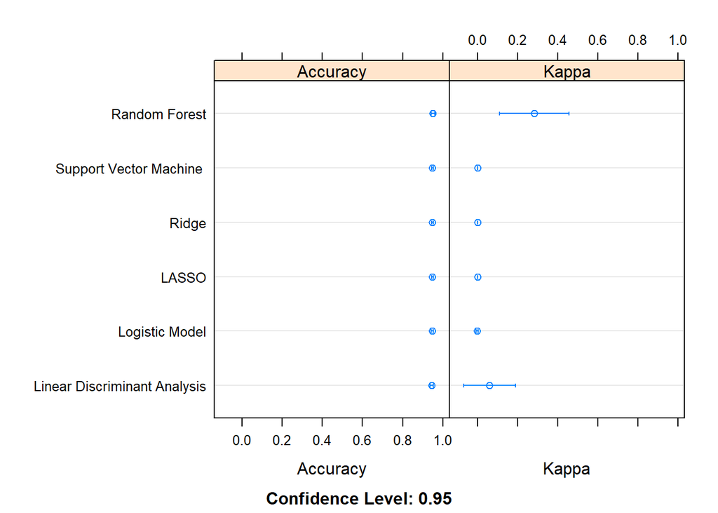

```r
dotplot(results)
```

```r
# summarize Best Model
print(fit.rf_wfh)
```

```
## Random Forest
##
## 933 samples
##  12 predictor
##   2 classes: '0', '1'
##
## No pre-processing
## Resampling: Cross-Validated (5 fold)
## Summary of sample sizes: 747, 746, 746, 746, 747
## Resampling results across tuning parameters:
##
##   mtry  Accuracy   Kappa
##    2    0.9485596  0.00000000
##    3    0.9485596  0.00000000
##    5    0.9485538  0.06961139
##    6    0.9453395  0.02788707
##    8    0.9474786  0.09491627
##   10    0.9474786  0.09491627
##   11    0.9464033  0.09353968
##   13    0.9474843  0.12039585
##   15    0.9496119  0.18312214
##   16    0.9496176  0.20920780
##   18    0.9517682  0.28385107
##   20    0.9506929  0.23913584
##   21    0.9517682  0.30203072
##   23    0.9496291  0.29066642
##   25    0.9506986  0.31539587
##
## Accuracy was used to select the optimal model using the largest value.
## The final value used for the model was mtry = 18.
```

## Confusion matrix

```r
# estimate skill of all models  on the validation dataset
predictions <- predict(fit.lda_wfh, test.wfh_dummy)
confusionMatrix(predictions, test.wfh_dummy$wfh_dummy,positive="1")
```

```
## Confusion Matrix and Statistics
##
##           Reference
## Prediction   0   1
##          0 586  29
##          1   3   2
##
##                Accuracy : 0.9484
##                  95% CI : (0.9279, 0.9644)
##     No Information Rate : 0.95
##     P-Value [Acc > NIR] : 0.6186
##
##                   Kappa : 0.0986
##
##  Mcnemar's Test P-Value : 9.897e-06
##
##             Sensitivity : 0.064516
##             Specificity : 0.994907
##          Pos Pred Value : 0.400000
##          Neg Pred Value : 0.952846
##              Prevalence : 0.050000
##          Detection Rate : 0.003226
##    Detection Prevalence : 0.008065
##       Balanced Accuracy : 0.529711
##
##        'Positive' Class : 1
##
```

```r
predictions <- predict(fit.logistic_wfh, test.wfh_dummy)
confusionMatrix(predictions, test.wfh_dummy$wfh_dummy,positive="1")
```

```
## Confusion Matrix and Statistics
##
##           Reference
## Prediction   0   1
##          0 588  31
##          1   1   0
##
##                Accuracy : 0.9484
##                  95% CI : (0.9279, 0.9644)
##     No Information Rate : 0.95
##     P-Value [Acc > NIR] : 0.6186
##
##                   Kappa : -0.0031
##
##  Mcnemar's Test P-Value : 2.951e-07
##
##             Sensitivity : 0.000000
##             Specificity : 0.998302
##          Pos Pred Value : 0.000000
##          Neg Pred Value : 0.949919
##              Prevalence : 0.050000
##          Detection Rate : 0.000000
##    Detection Prevalence : 0.001613
##       Balanced Accuracy : 0.499151
##
##        'Positive' Class : 1
##
```

```r
predictions <- predict(fit.svm_wfh, test.wfh_dummy)
confusionMatrix(predictions, test.wfh_dummy$wfh_dummy,positive="1")
```

```
## Confusion Matrix and Statistics
##
##           Reference
## Prediction   0   1
##          0 589  31
##          1   0   0
##
##                Accuracy : 0.95
##                  95% CI : (0.9298, 0.9658)
##     No Information Rate : 0.95
##     P-Value [Acc > NIR] : 0.5476
##
##                   Kappa : 0
##
##  Mcnemar's Test P-Value : 7.118e-08
##
##             Sensitivity : 0.00
##             Specificity : 1.00
##          Pos Pred Value :  NaN
##          Neg Pred Value : 0.95
##              Prevalence : 0.05
##          Detection Rate : 0.00
##    Detection Prevalence : 0.00
##       Balanced Accuracy : 0.50
##
##        'Positive' Class : 1
##
```

```r
predictions <- predict(fit.rf_wfh, test.wfh_dummy)
confusionMatrix(predictions, test.wfh_dummy$wfh_dummy,positive="1")
```

```
## Confusion Matrix and Statistics
##
##           Reference
## Prediction   0   1
##          0 582  28
##          1   7   3
##
##                Accuracy : 0.9435
##                  95% CI : (0.9224, 0.9604)
##     No Information Rate : 0.95
##     P-Value [Acc > NIR] : 0.7990758
##
##                   Kappa : 0.125
##
##  Mcnemar's Test P-Value : 0.0007232
##
##             Sensitivity : 0.096774
##             Specificity : 0.988115
##          Pos Pred Value : 0.300000
##          Neg Pred Value : 0.954098
##              Prevalence : 0.050000
##          Detection Rate : 0.004839
##    Detection Prevalence : 0.016129
##       Balanced Accuracy : 0.542445
##
##        'Positive' Class : 1
##
```

```r
predictions <- predict(fit.lasso_wfh, test.wfh_dummy)
confusionMatrix(predictions, test.wfh_dummy$wfh_dummy,positive="1")
```

```
## Confusion Matrix and Statistics
##
##           Reference
## Prediction   0   1
##          0 589  31
##          1   0   0
##
##                Accuracy : 0.95
##                  95% CI : (0.9298, 0.9658)
##     No Information Rate : 0.95
##     P-Value [Acc > NIR] : 0.5476
##
##                   Kappa : 0
##
##  Mcnemar's Test P-Value : 7.118e-08
##
##             Sensitivity : 0.00
##             Specificity : 1.00
##          Pos Pred Value :  NaN
##          Neg Pred Value : 0.95
##              Prevalence : 0.05
##          Detection Rate : 0.00
##    Detection Prevalence : 0.00
##       Balanced Accuracy : 0.50
##
##        'Positive' Class : 1
##
```

```r
predictions <- predict(fit.ridge_wfh, test.wfh_dummy)
confusionMatrix(predictions, test.wfh_dummy$wfh_dummy,positive="1")
```

```
## Confusion Matrix and Statistics
##
##           Reference
## Prediction   0   1
##          0 589  31
##          1   0   0
##
##                Accuracy : 0.95
##                  95% CI : (0.9298, 0.9658)
##     No Information Rate : 0.95
##     P-Value [Acc > NIR] : 0.5476
##
##                   Kappa : 0
##
##  Mcnemar's Test P-Value : 7.118e-08
##
##             Sensitivity : 0.00
##             Specificity : 1.00
##          Pos Pred Value :  NaN
##          Neg Pred Value : 0.95
##              Prevalence : 0.05
##          Detection Rate : 0.00
##    Detection Prevalence : 0.00
##       Balanced Accuracy : 0.50
##
##        'Positive' Class : 1
##
```

## Variable of importance

```r
varImp(fit.lda_wfh)
```

```
## ROC curve variable importance
##
##              Importance
## wt              100.000
## age              65.682
## bwt              27.651
## wealth_index     20.977
## residence        20.642
## region           19.788
## gender           18.704
## num_child        17.567
## educ_mum         10.412
## diarrhea          3.329
## source_water      2.949
## birth_order       0.000
```

```r
varImp(fit.logistic_wfh)
```

```
## glmnet variable importance
##
##   only 20 most important variables shown (out of 25)
##
##                        Overall
## regionCentral          100.000
## wealth_indexMiddle      68.623
## genderFemale            17.159
## wealth_indexRicher       3.363
## wt                       2.355
## regionAshanti            1.369
## educ_mumHigher           0.255
## wealth_indexRichest      0.000
## wealth_indexPoorer       0.000
## regionNothern            0.000
## regionEastern            0.000
## regionUpper East         0.000
## educ_mumSecondary        0.000
## regionUpper West         0.000
## educ_mumPrimary          0.000
## source_waterUnimproved   0.000
## birth_order              0.000
## residenceRural           0.000
## regionVolta              0.000
## regionBrong-Ahafo        0.000
```

```r
varImp(fit.svm_wfh)
```

```
## ROC curve variable importance
##
##              Importance
## wt              100.000
## age              65.682
## bwt              27.651
## wealth_index     20.977
## residence        20.642
## region           19.788
## gender           18.704
## num_child        17.567
## educ_mum         10.412
## diarrhea          3.329
## source_water      2.949
## birth_order       0.000
```

```r
varImp(fit.rf_wfh)
```

```
## rf variable importance
##
##   only 20 most important variables shown (out of 25)
##
##                     Overall
## wt                  100.000
## age                  89.929
## bwt                  34.726
## birth_order          22.056
## num_child            16.471
## regionUpper East      9.625
## wealth_indexRicher    8.546
## genderFemale          7.389
## wealth_indexRichest   5.475
## educ_mumSecondary     5.384
## regionUpper West      5.324
## diarrheaYes           4.767
## residenceRural        4.722
## regionCentral         4.532
## wealth_indexPoorer    4.178
## educ_mumPrimary       3.833
## regionBrong-Ahafo     3.461
## wealth_indexMiddle    3.327
## regionGreater Accra   2.553
## regionAshanti         1.904
```

```r
varImp(fit.lasso_wfh)
```

```
## glmnet variable importance
##
##   only 20 most important variables shown (out of 25)
##
##                        Overall
## wt                         NaN
## regionBrong-Ahafo          NaN
## regionNothern              NaN
## wealth_indexPoorer         NaN
## regionUpper West           NaN
## educ_mumPrimary            NaN
## birth_order                NaN
## educ_mumHigher             NaN
## regionGreater Accra        NaN
## educ_mumSecondary          NaN
## source_waterUnimproved     NaN
## regionCentral              NaN
## genderFemale               NaN
## residenceRural             NaN
## age                        NaN
## regionUpper East           NaN
## diarrheaYes                NaN
## bwt                        NaN
## wealth_indexRichest        NaN
## num_child                  NaN
```

```r
varImp(fit.ridge_wfh)
```

```
## glmnet variable importance
##
##   only 20 most important variables shown (out of 25)
##
##                        Overall
## regionCentral          100.000
## regionUpper East        43.514
## wealth_indexMiddle      43.297
## educ_mumHigher          35.253
## wealth_indexRicher      33.948
## genderFemale            30.970
## regionAshanti           27.472
## residenceRural          22.882
## bwt                     21.677
## regionEastern           20.038
## educ_mumSecondary       18.113
## regionVolta             17.237
## regionBrong-Ahafo       16.670
## source_waterUnimproved  14.133
## educ_mumPrimary         12.774
## diarrheaYes             12.170
## wealth_indexPoorer      10.986
## regionNothern            7.806
## regionUpper West         7.374
## num_child                4.196
```

```r
varImp(fit.lda_wfh,scale=FALSE)
```

```
## ROC curve variable importance
##
##              Importance
## wt               0.8639
## age              0.7396
## bwt              0.6017
## wealth_index     0.5776
## residence        0.5763
## region           0.5732
## gender           0.5693
## num_child        0.5652
## educ_mum         0.5393
## diarrhea         0.5136
## source_water     0.5122
## birth_order      0.5015
```

```r
varImp(fit.logistic_wfh,scale=FALSE)
```

```
## glmnet variable importance
##
##   only 20 most important variables shown (out of 25)
##
##                         Overall
## regionCentral          1.245598
## wealth_indexMiddle     0.854767
## genderFemale           0.213736
## wealth_indexRicher     0.041894
## wt                     0.029329
## regionAshanti          0.017048
## educ_mumHigher         0.003177
## regionUpper West       0.000000
## num_child              0.000000
## regionGreater Accra    0.000000
## educ_mumPrimary        0.000000
## wealth_indexPoorer     0.000000
## birth_order            0.000000
## bwt                    0.000000
## diarrheaYes            0.000000
## regionNothern          0.000000
## regionVolta            0.000000
## source_waterUnimproved 0.000000
## residenceRural         0.000000
## regionUpper East       0.000000
```

```r
varImp(fit.svm_wfh,scale=FALSE)
```

```
## ROC curve variable importance
##
##              Importance
## wt               0.8639
## age              0.7396
## bwt              0.6017
## wealth_index     0.5776
## residence        0.5763
## region           0.5732
## gender           0.5693
## num_child        0.5652
## educ_mum         0.5393
## diarrhea         0.5136
## source_water     0.5122
## birth_order      0.5015
```

```r
varImp(fit.rf_wfh,scale=FALSE)
```

```
## rf variable importance
##
##   only 20 most important variables shown (out of 25)
##
##                     Overall
## wt                  25.4540
## age                 22.9062
## bwt                  8.9408
## birth_order          5.7354
## num_child            4.3225
## regionUpper East     2.5905
## wealth_indexRicher   2.3177
## genderFemale         2.0250
## wealth_indexRichest  1.5406
## educ_mumSecondary    1.5178
## regionUpper West     1.5026
## diarrheaYes          1.3616
## residenceRural       1.3503
## regionCentral        1.3021
## wealth_indexPoorer   1.2125
## educ_mumPrimary      1.1254
## regionBrong-Ahafo    1.0312
## wealth_indexMiddle   0.9974
## regionGreater Accra  0.8015
## regionAshanti        0.6372
```

```r
varImp(fit.lasso_wfh,scale=FALSE)
```

```
## glmnet variable importance
##
##   only 20 most important variables shown (out of 25)
##
##                        Overall
## educ_mumHigher               0
## age                          0
## wealth_indexRicher           0
## wt                           0
## wealth_indexRichest          0
## residenceRural               0
## regionBrong-Ahafo            0
## wealth_indexPoorer           0
## regionNothern                0
## num_child                    0
## regionUpper West             0
## birth_order                  0
## regionUpper East             0
## regionVolta                  0
## educ_mumPrimary              0
## source_waterUnimproved       0
## bwt                          0
## regionCentral                0
## genderFemale                 0
## regionEastern                0
```

```r
varImp(fit.ridge_wfh,scale=FALSE)
```

```
## glmnet variable importance
##
##   only 20 most important variables shown (out of 25)
##
##                         Overall
## regionCentral          0.131693
## regionUpper East       0.057356
## wealth_indexMiddle     0.057070
## educ_mumHigher         0.046483
## wealth_indexRicher     0.044767
## genderFemale           0.040847
## regionAshanti          0.036243
## residenceRural         0.030203
## bwt                    0.028617
## regionEastern          0.026460
## educ_mumSecondary      0.023927
## regionVolta            0.022774
## regionBrong-Ahafo      0.022027
## source_waterUnimproved 0.018689
## educ_mumPrimary        0.016901
## diarrheaYes            0.016106
## wealth_indexPoorer     0.014547
## regionNothern          0.010362
## regionUpper West       0.009793
## num_child              0.005612
```

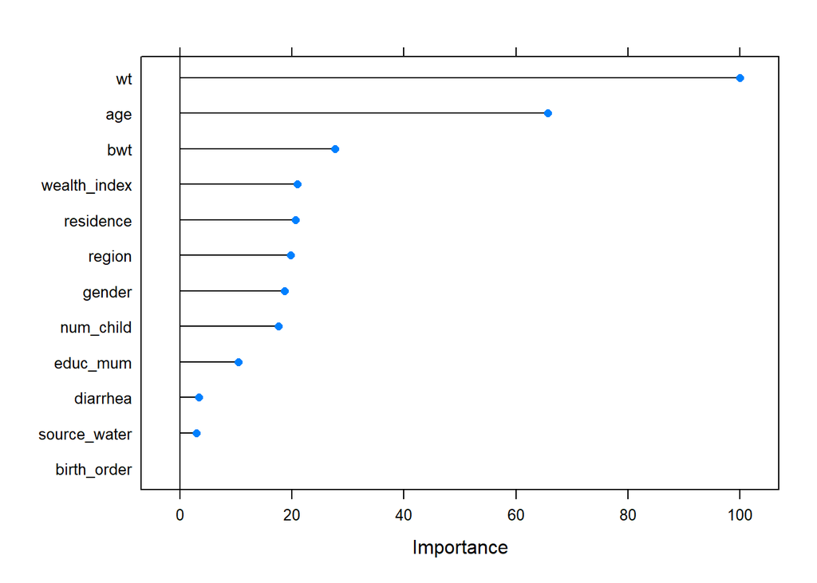

```r
plot(varImp(fit.lda_wfh))
```

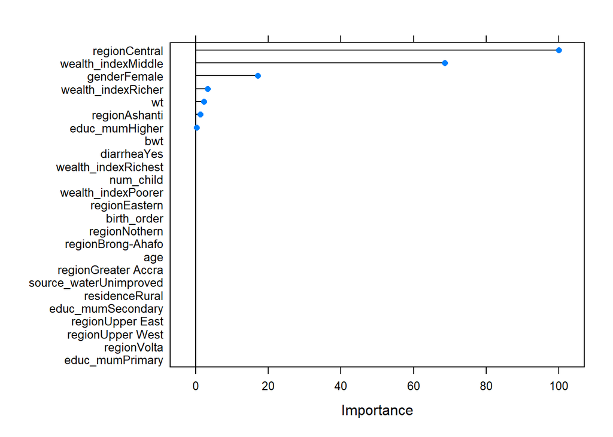

```r
plot(varImp(fit.logistic_wfh))
```

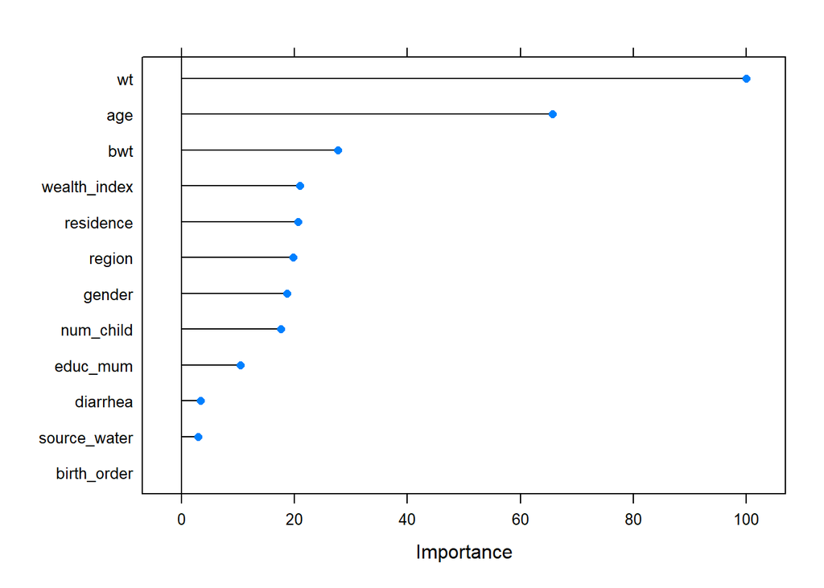

```r
plot(varImp(fit.svm_wfh))
```

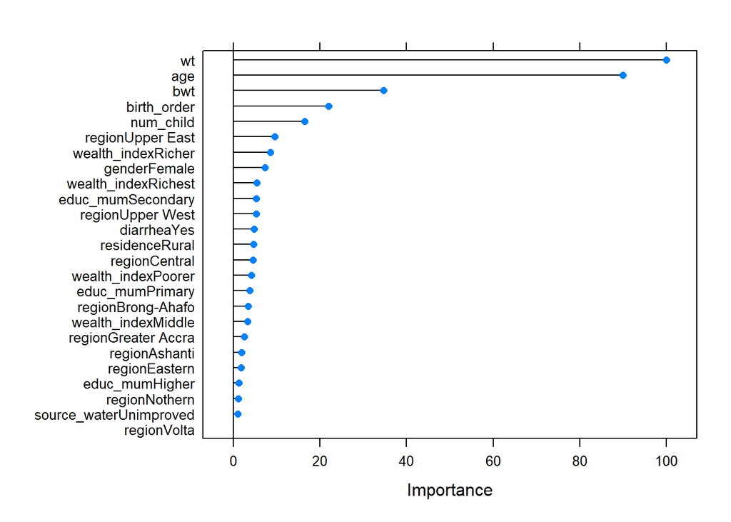

```r
plot(varImp(fit.rf_wfh))
```

[figure not shown]

```r
plot(varImp(fit.lasso_wfh))
```

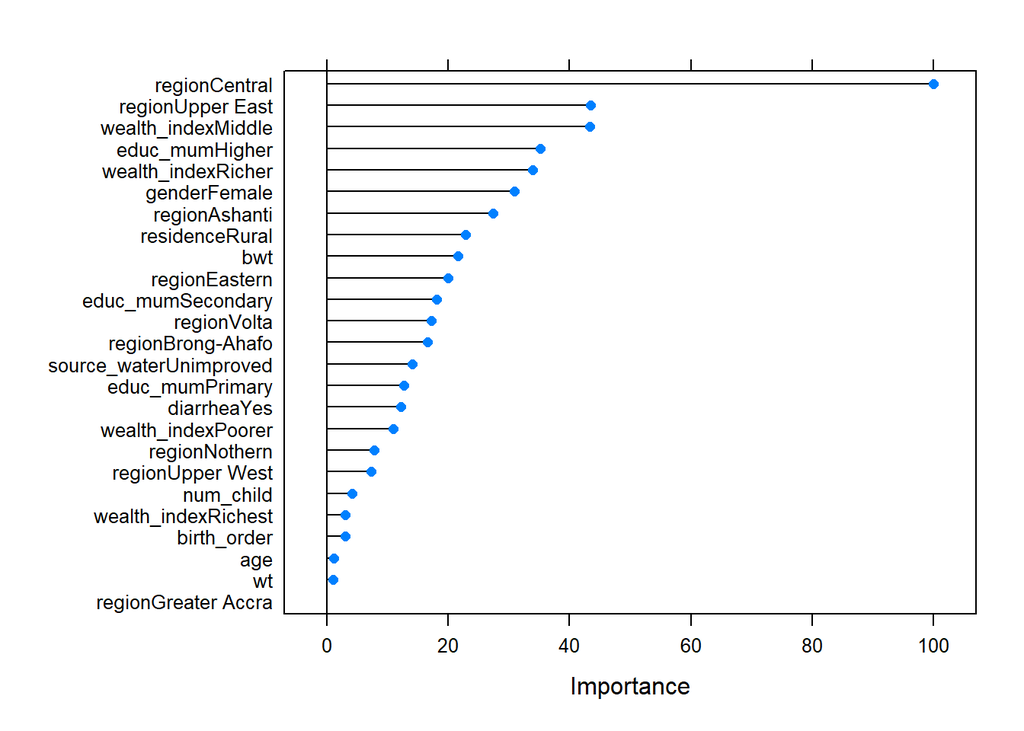

```r
plot(varImp(fit.ridge_wfh))
```

## Wasting: ROC Curves

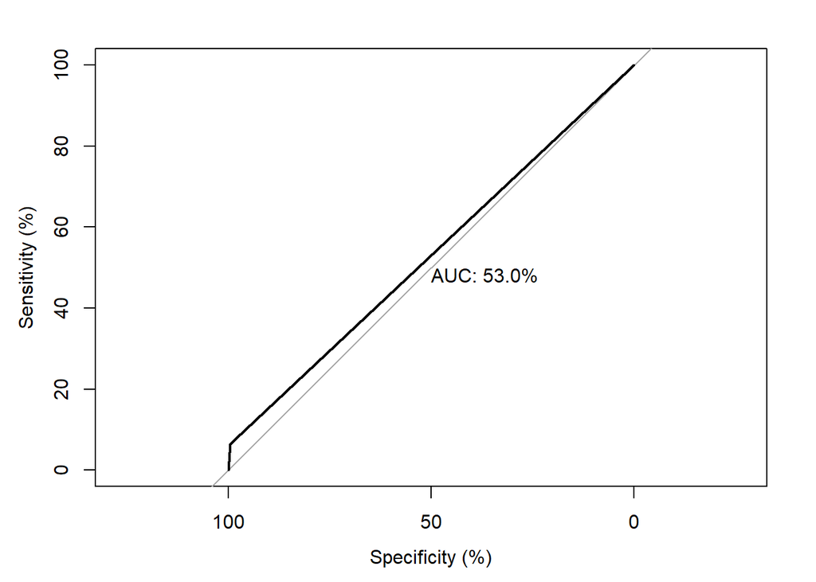

```r
test_prob_lda = predict(fit.lda_wfh, newdata = test.wfh_dummy, probability=TRUE)
test_roc_lda = roc(test.wfh_dummy$wfh_dummy ~ factor(test_prob_lda,ordered=TRUE), plot = TRUE, print.auc = TRUE,percent=TRUE,ordered=TRUE)
```

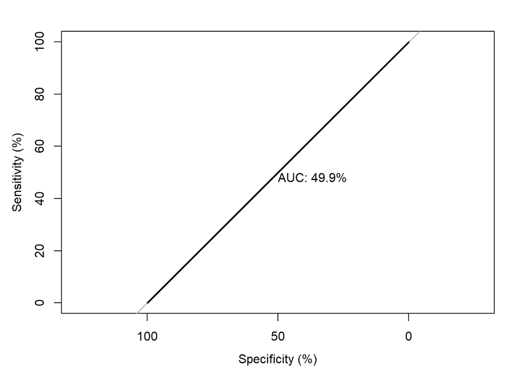

```r
test_prob_logistic = predict(fit.logistic_wfh, newdata = test.wfh_dummy, probability=TRUE)
test_roc_logistic = roc(test.wfh_dummy$wfh_dummy ~ factor(test_prob_logistic,ordered=TRUE), plot = TRUE, print.auc = TRUE,percent=TRUE,ordered=TRUE)
```

```r
test_prob_svm= predict(fit.svm_wfh, newdata = test.wfh_dummy, probability=TRUE)
test_roc_svm = roc(test.wfh_dummy$wfh_dummy ~ factor(test_prob_svm,ordered=TRUE), plot = TRUE, print.auc = TRUE,percent=TRUE,ordered=TRUE)
```

[output not shown]

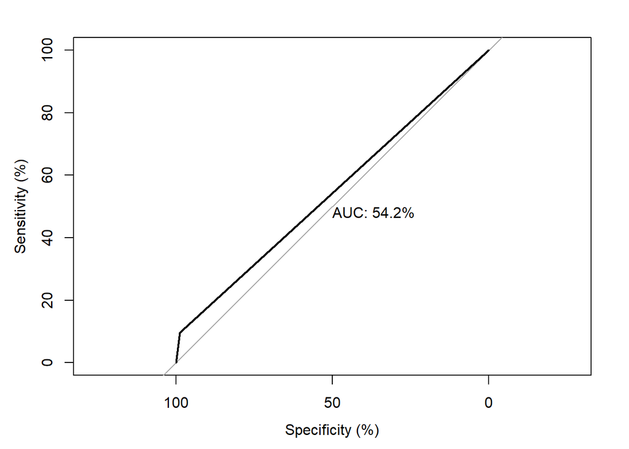

```r
test_prob_rf= predict(fit.rf_wfh, newdata = test.wfh_dummy, probability=TRUE)
test_roc_rf = roc(test.wfh_dummy$wfh_dummy ~ factor(test_prob_rf,ordered=TRUE), plot = TRUE, print.auc = TRUE,percent=TRUE,ordered=TRUE)
```

```r
test_prob_lasso= predict(fit.lasso_wfh, newdata = test.wfh_dummy, probability=TRUE)
test_roc_lasso = roc(test.wfh_dummy$wfh_dummy ~ factor(test_prob_lasso,ordered=TRUE), plot = TRUE, print.auc = TRUE,percent=TRUE,ordered=TRUE)
```

[output not shown]

```r
test_prob_ridge= predict(fit.ridge_wfh, newdata = test.wfh_dummy, probability=TRUE)
test_roc_ridge= roc(test.wfh_dummy$wfh_dummy ~ factor(test_prob_ridge,ordered=TRUE), plot = TRUE, print.auc = TRUE,percent=TRUE,ordered=TRUE)
```

[output not shown]

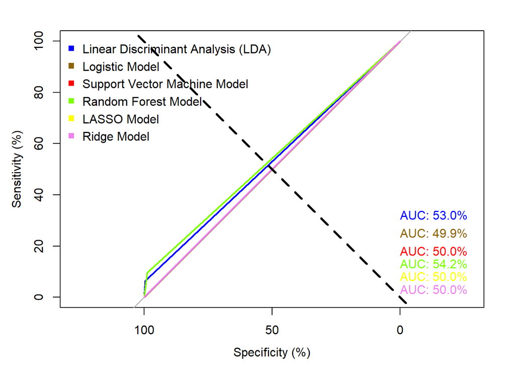

```r
plot(test_roc_lda,    print.auc = TRUE,  col='blue',percent=TRUE, print.auc.y = 34, print.auc.x = 0)
plot(test_roc_logistic, add = TRUE, col='darkgoldenrod4', print.auc = TRUE, print.auc.y = 27, print.auc.x = 0)
plot(test_roc_svm , add = TRUE, col='red', print.auc = TRUE, print.auc.y = 20, print.auc.x = 0)
plot(test_roc_rf , add = TRUE, col='chartreuse', print.auc = TRUE, print.auc.y = 15, print.auc.x = 0)
plot(test_roc_lasso , add = TRUE, col='yellow', print.auc = TRUE, print.auc.y = 10, print.auc.x = 0)
plot(test_roc_ridge , add = TRUE, col='violet', print.auc = TRUE, print.auc.y = 5, print.auc.x = 0)
abline(a=0, b=1, lty=2, lwd=3, col="black")
legend("topleft", legend = c("Linear Discriminant Analysis (LDA)","Logistic Model","Support Vector Machine Model","Random Forest Model","LASSO Model","Ridge Model") , pch = 15, bty = 'n', col = c("blue","darkgoldenrod4", "red","chartreuse","yellow","violet"))
```

# ML: Stunting

```r
set.seed(7)
# a) Linear Discriminant Analysis
fit.lda_hfa <- train(hfa_dummy~residence + age  + birth_order + gender + bwt  +num_child  +educ_mum +wealth_index  +diarrhea +wt+region +source_water, data=train.hfa_dummy, method="lda", metric=metric, trControl=control,weight=train.hfa_dummy$Sample_wt,tuneLength=15)

# Support vector machine
set.seed(7)
fit.svm_hfa <- train(hfa_dummy~residence + age  + birth_order + gender + bwt  +num_child  +educ_mum +wealth_index  +diarrhea +wt+region +source_water, data=train.hfa_dummy, method="svmRadial", metric=metric, trControl=control,weight=train.hfa_dummy$Sample_wt,tuneLength=15)

# Logistic Model
set.seed(7)
fit.logistic_hfa <- train(hfa_dummy~residence + age  + birth_order + gender + bwt  +num_child  +educ_mum +wealth_index+diarrhea +wt+region +source_water, data=train.hfa_dummy, method="glmnet", metric=metric, trControl=control,weights=train.hfa_dummy$Sample_wt,family="binomial")

# Random forest Model
set.seed(7)
fit.rf_hfa <- train(hfa_dummy~residence + age  + birth_order + gender + bwt  +num_child  +educ_mum +wealth_index+diarrhea +wt+region +source_water, data=train.hfa_dummy, method="rf", metric=metric, trControl=control,weights=train.hfa_dummy$Sample_wt,tuneLength=15)

# LASSO Model with vector lambda
set.seed(7)
fit.lasso_hfa <- train(hfa_dummy~residence + age  + birth_order + gender + bwt  +num_child  +educ_mum +wealth_index+diarrhea +wt+region +source_water, data=train.hfa_dummy, method="glmnet", metric=metric, trControl=control,weights=train.hfa_dummy$Sample_wt,tuneGrid=expand.grid(alpha=1,lambda=lambda_vector))

# Get the optimal tunning parameter for the lasso
bestlambda_Lasso<-fit.lasso_hfa$bestTune$lambda
bestlambda_Lasso
```

```
## [1] 0.01
```

```r
# refit the lasso model with the best lambda value
set.seed(7)
fit.lasso_hfa <- train(hfa_dummy~residence + age  + birth_order + gender + bwt  +num_child  +educ_mum +wealth_index+diarrhea +wt+region +source_water, data=train.hfa_dummy, method="glmnet", metric=metric, trControl=control,weights=train.hfa_dummy$Sample_wt,tuneGrid=expand.grid(alpha=1,lambda=bestlambda_Lasso))



# Ridge Regression
set.seed(7)
fit.ridge_hfa <- train(hfa_dummy~residence + age  + birth_order + gender + bwt  +num_child  +educ_mum +wealth_index+diarrhea +wt+region +source_water, data=train.hfa_dummy, method="glmnet", metric=metric, trControl=control,weights=train.hfa_dummy$Sample_wt,tuneGrid=expand.grid(alpha=0,lambda=lambda_vector))

# Get the optimal tunning parameter for the ridge
bestlambda_ridge<-fit.ridge_hfa$bestTune$lambda
bestlambda_ridge
```

```
## [1] 0
```

```r
# fit the final ridge model with best lambda values
set.seed(7)
fit.ridge_hfa <- train(hfa_dummy~residence + age  + birth_order + gender + bwt  +num_child  +educ_mum +wealth_index+diarrhea +wt+region +source_water, data=train.hfa_dummy, method="glmnet", metric=metric, trControl=control,weights=train.hfa_dummy$Sample_wt,tuneGrid=expand.grid(alpha=0,lambda=bestlambda_ridge))
```

```r
results <- results <- resamples(list("Linear Discriminant Analysis" =fit.lda_hfa,"Logistic Model"=fit.logistic_hfa, "Support Vector Machine " =fit.svm_hfa,"Random Forest" =fit.rf_hfa,LASSO=fit.lasso_hfa,Ridge=fit.ridge_hfa))
summary(results)
```

```
##
## Call:
## summary.resamples(object = results)
##
## Models: Linear Discriminant Analysis, Logistic Model, Support Vector Machine , Random Forest, LASSO, Ridge
## Number of resamples: 5
##
## Accuracy
##                                   Min.   1st Qu.    Median      Mean   3rd Qu.
## Linear Discriminant Analysis 0.8294931 0.8341014 0.8348624 0.8464804 0.8577982
## Logistic Model               0.8440367 0.8479263 0.8486239 0.8492665 0.8525346
## Support Vector Machine       0.8440367 0.8479263 0.8479263 0.8474274 0.8486239
## Random Forest                0.8532110 0.8623853 0.8669725 0.8722741 0.8894009
## LASSO                        0.8479263 0.8486239 0.8525346 0.8511013 0.8532110
## Ridge                        0.8165138 0.8525346 0.8525346 0.8501881 0.8623853
##                                   Max. NA's
## Linear Discriminant Analysis 0.8761468    0
## Logistic Model               0.8532110    0
## Support Vector Machine       0.8486239    0
## Random Forest                0.8894009    0
## LASSO                        0.8532110    0
## Ridge                        0.8669725    0
##
## Kappa
##                                     Min.   1st Qu.     Median       Mean
## Linear Discriminant Analysis  0.10520450 0.1144865 0.11482066 0.16707285
## Logistic Model                0.00000000 0.0000000 0.00000000 0.02013915
## Support Vector Machine        0.00000000 0.0000000 0.00000000 0.00000000
## Random Forest                 0.18996749 0.2989576 0.33115156 0.34904187
## LASSO                         0.00000000 0.0000000 0.05032823 0.03922629
## Ridge                        -0.01845363 0.0879958 0.15502555 0.12567520
##                                 3rd Qu.       Max. NA's
## Linear Discriminant Analysis 0.19643282 0.30441976    0
## Logistic Model               0.05032823 0.05036755    0
## Support Vector Machine       0.00000000 0.00000000    0
## Random Forest                0.42919772 0.49593496    0
## LASSO                        0.05036755 0.09543568    0
## Ridge                        0.18372441 0.22008389    0
```

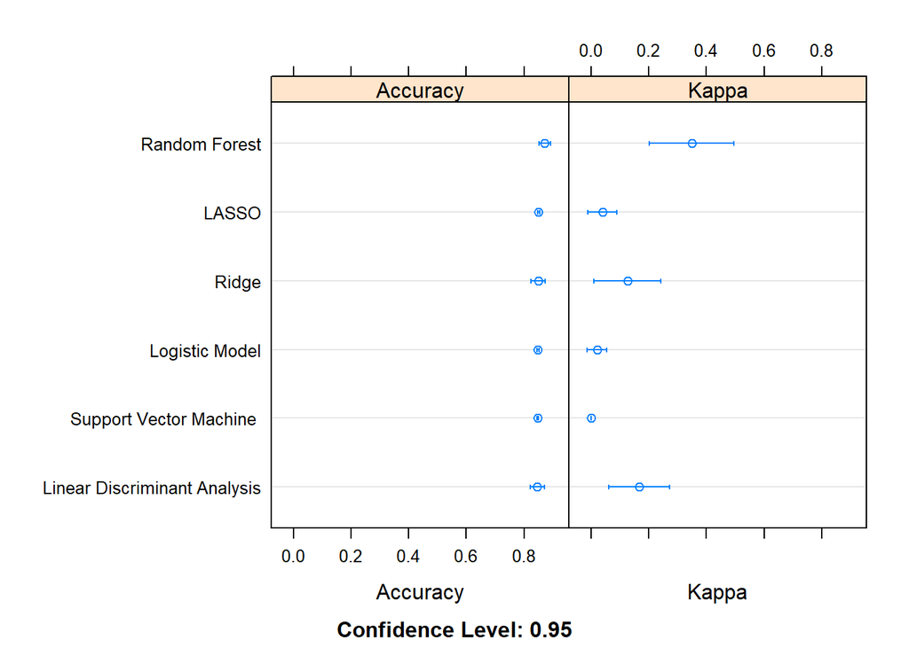

```r
dotplot(results)
```

```r
# summarize Best Model
print(fit.rf_hfa)
```

```
## Random Forest
##
## 1088 samples
##   12 predictor
##    2 classes: '0', '1'
##
## No pre-processing
## Resampling: Cross-Validated (5 fold)
## Summary of sample sizes: 870, 870, 871, 871, 870
## Resampling results across tuning parameters:
##
##   mtry  Accuracy   Kappa
##    2    0.8474274  0.00000000
##    3    0.8511056  0.06329231
##    5    0.8557139  0.14761327
##    6    0.8603095  0.18922821
##    8    0.8649093  0.24624287
##   10    0.8686002  0.28649199
##   11    0.8676827  0.29650733
##   13    0.8713609  0.32187489
##   15    0.8649220  0.30868341
##   16    0.8722699  0.33956638
##   18    0.8722741  0.34904187
##   20    0.8685833  0.32864955
##   21    0.8722699  0.35404881
##   23    0.8722657  0.35414778
##   25    0.8713482  0.35122814
##
## Accuracy was used to select the optimal model using the largest value.
## The final value used for the model was mtry = 18.
```

## Confusion matrix

```r
# estimate skill of all hfa models  on the validation dataset
predictions <- predict(fit.lda_hfa, test.hfa_dummy)
confusionMatrix(predictions, test.hfa_dummy$hfa_dummy,positive="1")
```

```
## Confusion Matrix and Statistics
##
##           Reference
## Prediction   0   1
##          0 386  54
##          1   9  16
##
##                Accuracy : 0.8645
##                  95% CI : (0.83, 0.8943)
##     No Information Rate : 0.8495
##     P-Value [Acc > NIR] : 0.2008
##
##                   Kappa : 0.2798
##
##  Mcnemar's Test P-Value : 2.965e-08
##
##             Sensitivity : 0.22857
##             Specificity : 0.97722
##          Pos Pred Value : 0.64000
##          Neg Pred Value : 0.87727
##              Prevalence : 0.15054
##          Detection Rate : 0.03441
##    Detection Prevalence : 0.05376
##       Balanced Accuracy : 0.60289
##
##        'Positive' Class : 1
##
```

```r
predictions <- predict(fit.logistic_hfa, test.hfa_dummy)
confusionMatrix(predictions, test.hfa_dummy$hfa_dummy,positive="1")
```

```
## Confusion Matrix and Statistics
##
##           Reference
## Prediction   0   1
##          0 395  67
##          1   0   3
##
##                Accuracy : 0.8559
##                  95% CI : (0.8207, 0.8866)
##     No Information Rate : 0.8495
##     P-Value [Acc > NIR] : 0.3781
##
##                   Kappa : 0.0707
##
##  Mcnemar's Test P-Value : 7.433e-16
##
##             Sensitivity : 0.042857
##             Specificity : 1.000000
##          Pos Pred Value : 1.000000
##          Neg Pred Value : 0.854978
##              Prevalence : 0.150538
##          Detection Rate : 0.006452
##    Detection Prevalence : 0.006452
##       Balanced Accuracy : 0.521429
##
##        'Positive' Class : 1
##
```

```r
predictions <- predict(fit.svm_hfa, test.hfa_dummy)
confusionMatrix(predictions, test.hfa_dummy$hfa_dummy,positive="1")
```

```
## Confusion Matrix and Statistics
##
##           Reference
## Prediction   0   1
##          0 395  70
##          1   0   0
##
##                Accuracy : 0.8495
##                  95% CI : (0.8137, 0.8807)
##     No Information Rate : 0.8495
##     P-Value [Acc > NIR] : 0.5318
##
##                   Kappa : 0
##
##  Mcnemar's Test P-Value : <2e-16
##
##             Sensitivity : 0.0000
##             Specificity : 1.0000
##          Pos Pred Value :    NaN
##          Neg Pred Value : 0.8495
##              Prevalence : 0.1505
##          Detection Rate : 0.0000
##    Detection Prevalence : 0.0000
##       Balanced Accuracy : 0.5000
##
##        'Positive' Class : 1
##
```

```r
predictions <- predict(fit.rf_hfa, test.hfa_dummy)
confusionMatrix(predictions, test.hfa_dummy$hfa_dummy,positive="1")
```

```
## Confusion Matrix and Statistics
##
##           Reference
## Prediction   0   1
##          0 378  50
##          1  17  20
##
##                Accuracy : 0.8559
##                  95% CI : (0.8207, 0.8866)
##     No Information Rate : 0.8495
##     P-Value [Acc > NIR] : 0.3781
##
##                   Kappa : 0.3011
##
##  Mcnemar's Test P-Value : 9.252e-05
##
##             Sensitivity : 0.28571
##             Specificity : 0.95696
##          Pos Pred Value : 0.54054
##          Neg Pred Value : 0.88318
##              Prevalence : 0.15054
##          Detection Rate : 0.04301
##    Detection Prevalence : 0.07957
##       Balanced Accuracy : 0.62134
##
##        'Positive' Class : 1
##
```

```r
predictions <- predict(fit.lasso_hfa, test.hfa_dummy)
confusionMatrix(predictions, test.hfa_dummy$hfa_dummy,positive="1")
```

```
## Confusion Matrix and Statistics
##
##           Reference
## Prediction   0   1
##          0 395  67
##          1   0   3
##
##                Accuracy : 0.8559
##                  95% CI : (0.8207, 0.8866)
##     No Information Rate : 0.8495
##     P-Value [Acc > NIR] : 0.3781
##
##                   Kappa : 0.0707
##
##  Mcnemar's Test P-Value : 7.433e-16
##
##             Sensitivity : 0.042857
##             Specificity : 1.000000
##          Pos Pred Value : 1.000000
##          Neg Pred Value : 0.854978
##              Prevalence : 0.150538
##          Detection Rate : 0.006452
##    Detection Prevalence : 0.006452
##       Balanced Accuracy : 0.521429
##
##        'Positive' Class : 1
##
```

```r
predictions <- predict(fit.ridge_hfa, test.hfa_dummy)
confusionMatrix(predictions, test.hfa_dummy$hfa_dummy,positive="1")
```

```
## Confusion Matrix and Statistics
##
##           Reference
## Prediction   0   1
##          0 391  58
##          1   4  12
##
##                Accuracy : 0.8667
##                  95% CI : (0.8324, 0.8962)
##     No Information Rate : 0.8495
##     P-Value [Acc > NIR] : 0.1655
##
##                   Kappa : 0.2363
##
##  Mcnemar's Test P-Value : 1.685e-11
##
##             Sensitivity : 0.17143
##             Specificity : 0.98987
##          Pos Pred Value : 0.75000
##          Neg Pred Value : 0.87082
##              Prevalence : 0.15054
##          Detection Rate : 0.02581
##    Detection Prevalence : 0.03441
##       Balanced Accuracy : 0.58065
##
##        'Positive' Class : 1
##
```

## Variable of importance

```r
varImp(fit.lda_hfa)
```

```
## ROC curve variable importance
##
##              Importance
## bwt              100.00
## educ_mum          94.09
## wealth_index      89.58
## wt                64.12
## birth_order       62.66
## age               46.09
## num_child         36.60
## region            30.49
## gender            27.51
## diarrhea          19.78
## residence         17.87
## source_water       0.00
```

```r
varImp(fit.logistic_hfa)
```

```
## glmnet variable importance
##
##   only 20 most important variables shown (out of 25)
##
##                        Overall
## regionNothern          100.000
## genderFemale            56.591
## wealth_indexRichest     47.687
## bwt                     39.802
## regionVolta             38.015
## educ_mumSecondary       22.835
## birth_order             15.719
## regionEastern            9.592
## age                      8.764
## wt                       4.469
## regionCentral            0.000
## diarrheaYes              0.000
## source_waterUnimproved   0.000
## regionUpper East         0.000
## wealth_indexRicher       0.000
## wealth_indexMiddle       0.000
## educ_mumPrimary          0.000
## residenceRural           0.000
## regionBrong-Ahafo        0.000
## regionUpper West         0.000
```

```r
varImp(fit.svm_hfa)
```

```
## ROC curve variable importance
##
##              Importance
## bwt              100.00
## educ_mum          94.09
## wealth_index      89.58
## wt                64.12
## birth_order       62.66
## age               46.09
## num_child         36.60
## region            30.49
## gender            27.51
## diarrhea          19.78
## residence         17.87
## source_water       0.00
```

```r
varImp(fit.rf_hfa)
```

```
## rf variable importance
##
##   only 20 most important variables shown (out of 25)
##
##                     Overall
## age                 100.000
## wt                   99.639
## bwt                  50.197
## birth_order          36.046
## num_child            11.751
## regionNothern        11.480
## genderFemale         11.280
## educ_mumPrimary       6.382
## educ_mumSecondary     6.115
## residenceRural        6.035
## wealth_indexMiddle    5.130
## diarrheaYes           4.771
## wealth_indexPoorer    4.651
## regionBrong-Ahafo     4.523
## regionAshanti         4.459
## regionCentral         3.882
## regionVolta           3.713
## wealth_indexRicher    3.672
## wealth_indexRichest   3.234
## regionUpper West      3.131
```

```r
varImp(fit.lasso_hfa)
```

```
## glmnet variable importance
##
##   only 20 most important variables shown (out of 25)
##
##                     Overall
## regionNothern       100.000
## genderFemale         58.460
## wealth_indexRichest  47.677
## bwt                  39.724
## regionVolta          38.841
## educ_mumSecondary    22.964
## birth_order          15.850
## regionEastern        11.171
## age                   9.097
## wt                    4.637
## regionUpper East      0.000
## residenceRural        0.000
## regionGreater Accra   0.000
## wealth_indexMiddle    0.000
## regionBrong-Ahafo     0.000
## regionAshanti         0.000
## num_child             0.000
## educ_mumPrimary       0.000
## wealth_indexRicher    0.000
## educ_mumHigher        0.000
```

```r
varImp(fit.ridge_hfa)
```

```
## glmnet variable importance
##
##   only 20 most important variables shown (out of 25)
##
##                        Overall
## regionNothern          100.000
## wealth_indexRichest     80.547
## genderFemale            75.119
## regionVolta             57.977
## bwt                     47.421
## regionEastern           37.558
## source_waterUnimproved  36.385
## educ_mumSecondary       26.618
## residenceRural          26.093
## wealth_indexRicher      20.953
## diarrheaYes             15.551
## birth_order             14.505
## regionUpper East        14.017
## educ_mumHigher          13.800
## regionGreater Accra     13.004
## wealth_indexPoorer      12.088
## wealth_indexMiddle      11.131
## regionCentral           10.192
## age                      7.352
## regionAshanti            2.715
```

```r
varImp(fit.lda_hfa,scale=FALSE)
```

```
## ROC curve variable importance
##
##              Importance
## bwt              0.6067
## educ_mum         0.6008
## wealth_index     0.5963
## wt               0.5708
## birth_order      0.5694
## age              0.5528
## num_child        0.5433
## region           0.5373
## gender           0.5343
## diarrhea         0.5266
## residence        0.5246
## source_water     0.5068
```

```r
varImp(fit.logistic_hfa,scale=FALSE)
```

```
## glmnet variable importance
##
##   only 20 most important variables shown (out of 25)
##
##                     Overall
## regionNothern       0.73137
## genderFemale        0.41389
## wealth_indexRichest 0.34877
## bwt                 0.29110
## regionVolta         0.27803
## educ_mumSecondary   0.16700
## birth_order         0.11496
## regionEastern       0.07015
## age                 0.06409
## wt                  0.03268
## educ_mumPrimary     0.00000
## regionCentral       0.00000
## regionGreater Accra 0.00000
## regionBrong-Ahafo   0.00000
## wealth_indexPoorer  0.00000
## regionUpper East    0.00000
## educ_mumHigher      0.00000
## regionAshanti       0.00000
## num_child           0.00000
## residenceRural      0.00000
```

```r
varImp(fit.svm_hfa,scale=FALSE)
```

```
## ROC curve variable importance
##
##              Importance
## bwt              0.6067
## educ_mum         0.6008
## wealth_index     0.5963
## wt               0.5708
## birth_order      0.5694
## age              0.5528
## num_child        0.5433
## region           0.5373
## gender           0.5343
## diarrhea         0.5266
## residence        0.5246
## source_water     0.5068
```

```r
varImp(fit.rf_hfa,scale=FALSE)
```

```
## rf variable importance
##
##   only 20 most important variables shown (out of 25)
##
##                     Overall
## age                  64.907
## wt                   64.678
## bwt                  33.270
## birth_order          24.281
## num_child             8.848
## regionNothern         8.676
## genderFemale          8.549
## educ_mumPrimary       5.437
## educ_mumSecondary     5.268
## residenceRural        5.217
## wealth_indexMiddle    4.642
## diarrheaYes           4.414
## wealth_indexPoorer    4.338
## regionBrong-Ahafo     4.256
## regionAshanti         4.216
## regionCentral         3.849
## regionVolta           3.742
## wealth_indexRicher    3.716
## wealth_indexRichest   3.438
## regionUpper West      3.372
```

```r
varImp(fit.lasso_hfa,scale=FALSE)
```

```
## glmnet variable importance
##
##   only 20 most important variables shown (out of 25)
##
##                        Overall
## regionNothern          0.73568
## genderFemale           0.43008
## wealth_indexRichest    0.35075
## bwt                    0.29224
## regionVolta            0.28575
## educ_mumSecondary      0.16894
## birth_order            0.11660
## regionEastern          0.08219
## age                    0.06693
## wt                     0.03411
## source_waterUnimproved 0.00000
## educ_mumPrimary        0.00000
## regionCentral          0.00000
## educ_mumHigher         0.00000
## wealth_indexMiddle     0.00000
## residenceRural         0.00000
## num_child              0.00000
## diarrheaYes            0.00000
## regionUpper East       0.00000
## regionGreater Accra    0.00000
```

```r
varImp(fit.ridge_hfa,scale=FALSE)
```

```
## glmnet variable importance
##
##   only 20 most important variables shown (out of 25)
##
##                        Overall
## regionNothern          0.90455
## wealth_indexRichest    0.73292
## genderFemale           0.68503
## regionVolta            0.53379
## bwt                    0.44066
## regionEastern          0.35363
## source_waterUnimproved 0.34329
## educ_mumSecondary      0.25711
## residenceRural         0.25248
## wealth_indexRicher     0.20713
## diarrheaYes            0.15947
## birth_order            0.15024
## regionUpper East       0.14594
## educ_mumHigher         0.14402
## regionGreater Accra    0.13699
## wealth_indexPoorer     0.12891
## wealth_indexMiddle     0.12047
## regionCentral          0.11219
## age                    0.08713
## regionAshanti          0.04621
```

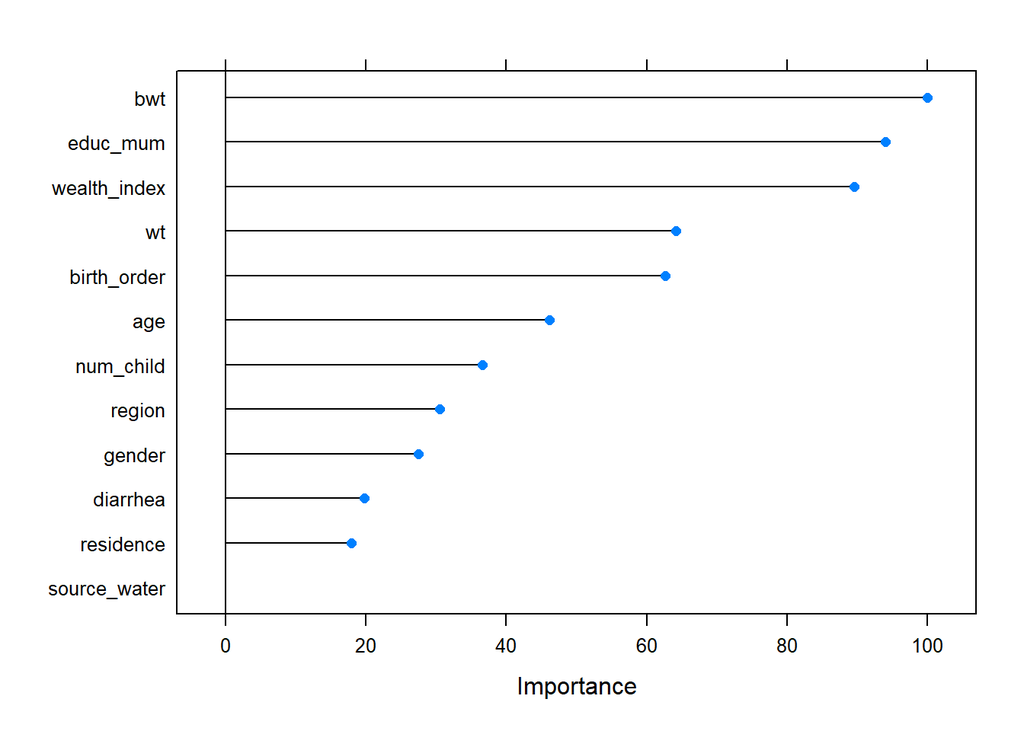

```r
plot(varImp(fit.lda_hfa))
```

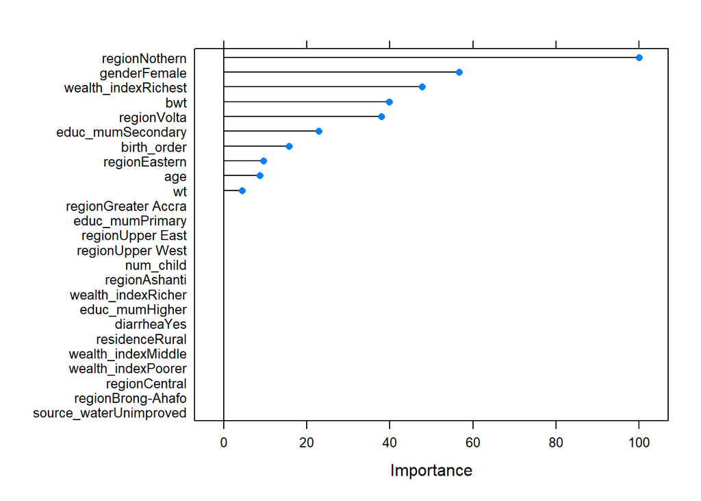

```r
plot(varImp(fit.logistic_hfa))
```

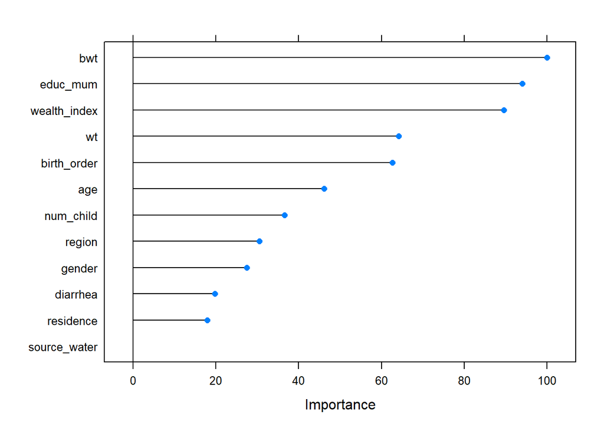

```r
plot(varImp(fit.svm_hfa))
```

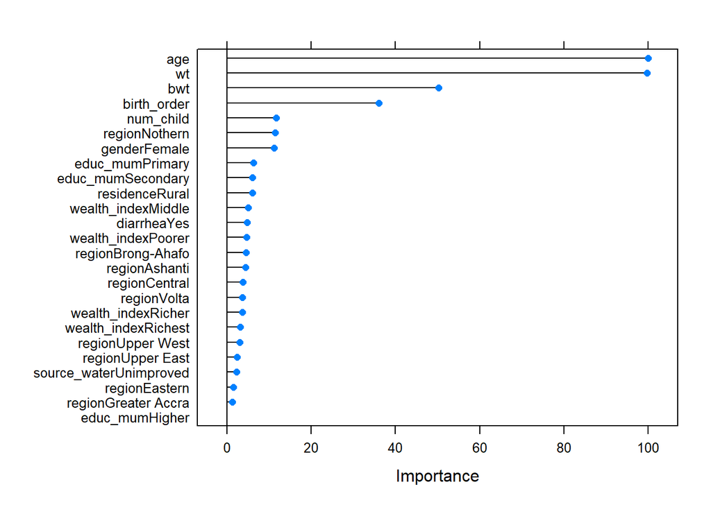

```r
plot(varImp(fit.rf_hfa))
```

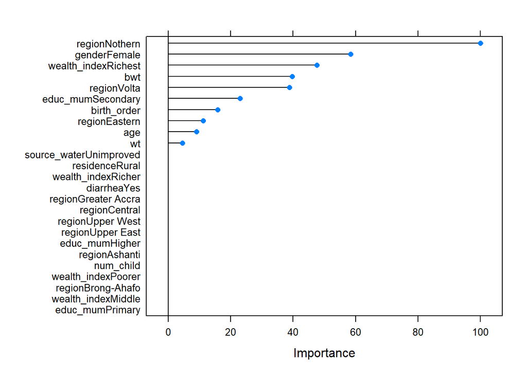

```r
plot(varImp(fit.lasso_hfa))
```

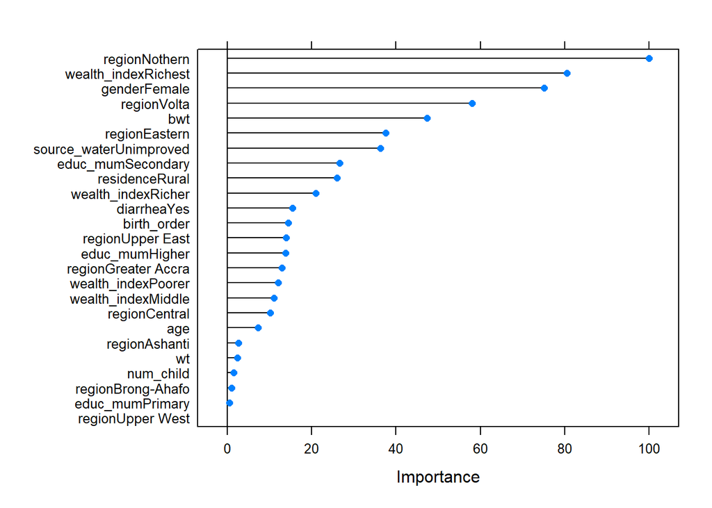

```r
plot(varImp(fit.ridge_hfa))
```

## ROC Curves

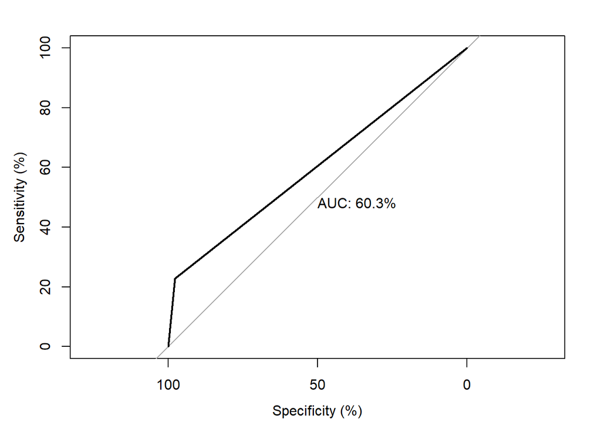

```r
test_prob_lda= predict(fit.lda_hfa, newdata = test.hfa_dummy, probability=TRUE)
test_roc_lda = roc(test.hfa_dummy$hfa_dummy ~ factor(test_prob_lda,ordered=TRUE), plot = TRUE, print.auc = TRUE,percent=TRUE,ordered=TRUE)
```

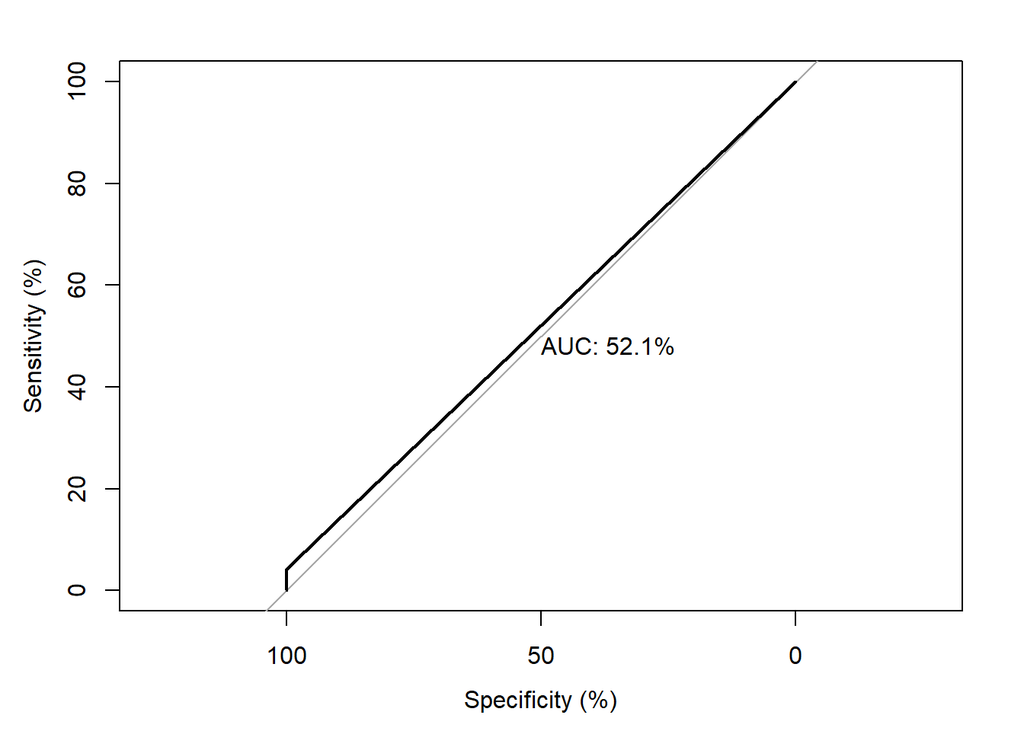

```r
test_prob_logistic = predict(fit.logistic_hfa, newdata = test.hfa_dummy, probability=TRUE)
test_roc_logistic = roc(test.hfa_dummy$hfa_dummy ~ factor(test_prob_logistic,ordered=TRUE), plot = TRUE, print.auc = TRUE,percent=TRUE,ordered=TRUE)
```

```r
test_prob_svm= predict(fit.svm_hfa, newdata = test.hfa_dummy, probability=TRUE)
test_roc_svm = roc(test.hfa_dummy$hfa_dummy ~ factor(test_prob_svm,ordered=TRUE), plot = TRUE, print.auc = TRUE,percent=TRUE,ordered=TRUE)
```

[output not shown]

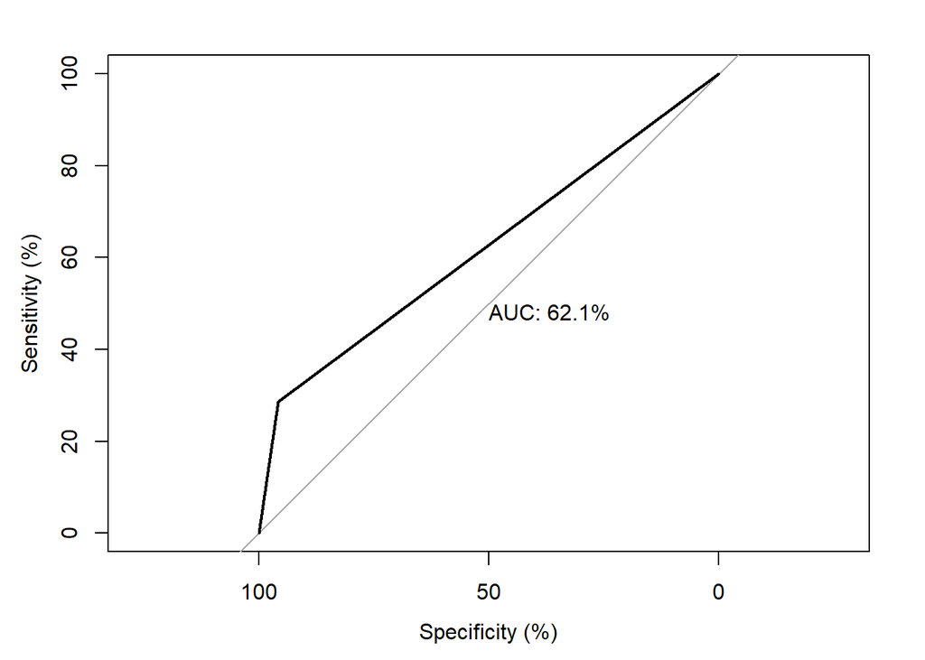

```r
test_prob_rf= predict(fit.rf_hfa, newdata = test.hfa_dummy, probability=TRUE)
test_roc_rf = roc(test.hfa_dummy$hfa_dummy ~ factor(test_prob_rf,ordered=TRUE), plot = TRUE, print.auc = TRUE,percent=TRUE,ordered=TRUE)
```

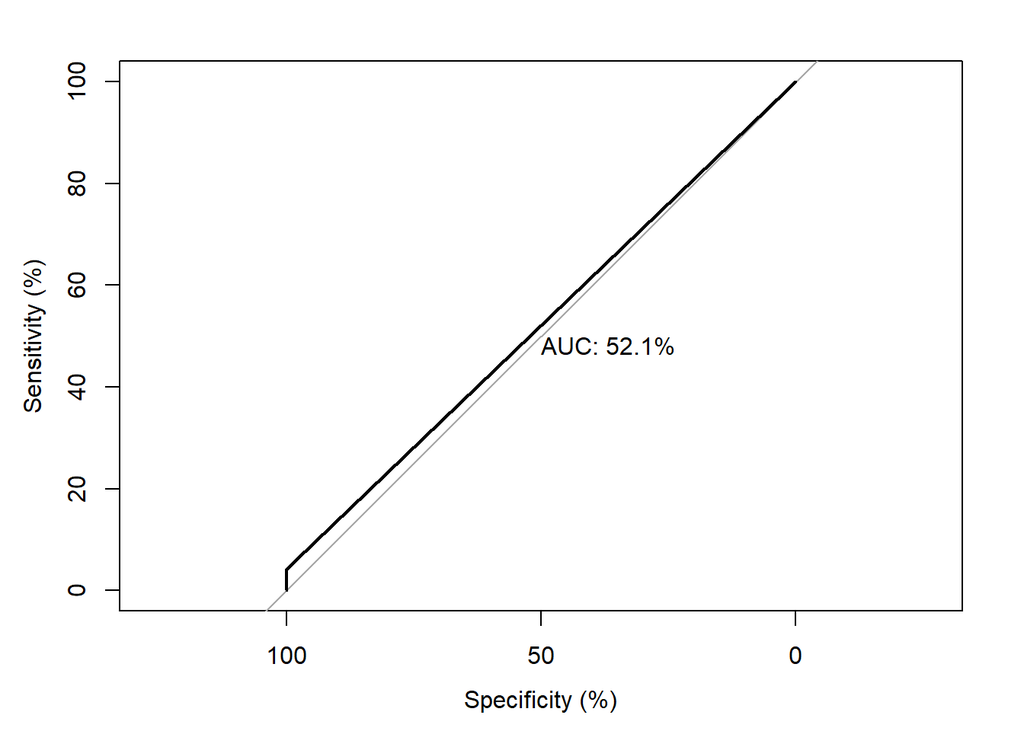

```r
test_prob_lasso= predict(fit.lasso_hfa, newdata = test.hfa_dummy, probability=TRUE)
test_roc_lasso = roc(test.hfa_dummy$hfa_dummy ~ factor(test_prob_lasso,ordered=TRUE), plot = TRUE, print.auc = TRUE,percent=TRUE,ordered=TRUE)
```

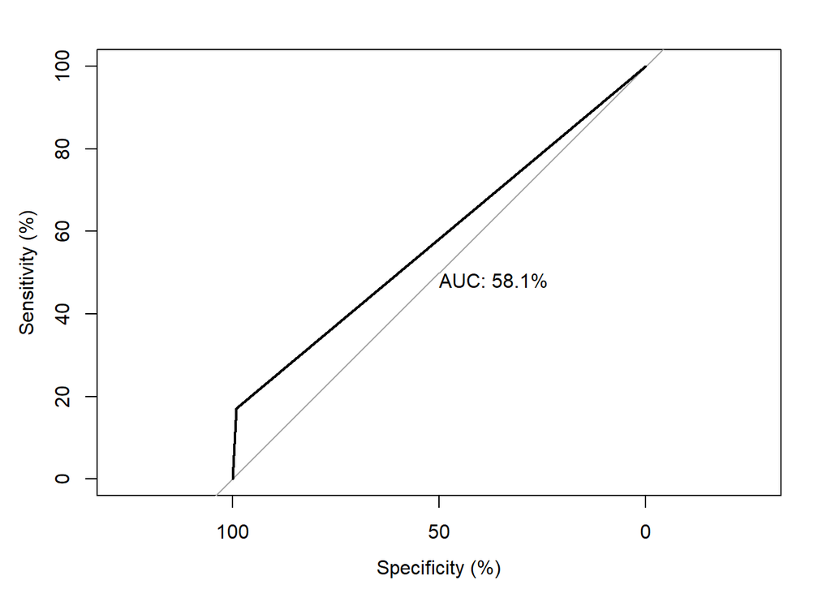

```r
test_prob_ridge= predict(fit.ridge_hfa, newdata = test.hfa_dummy, probability=TRUE)
test_roc_ridge= roc(test.hfa_dummy$hfa_dummy ~ factor(test_prob_ridge,ordered=TRUE), plot = TRUE, print.auc = TRUE,percent=TRUE,ordered=TRUE)
```

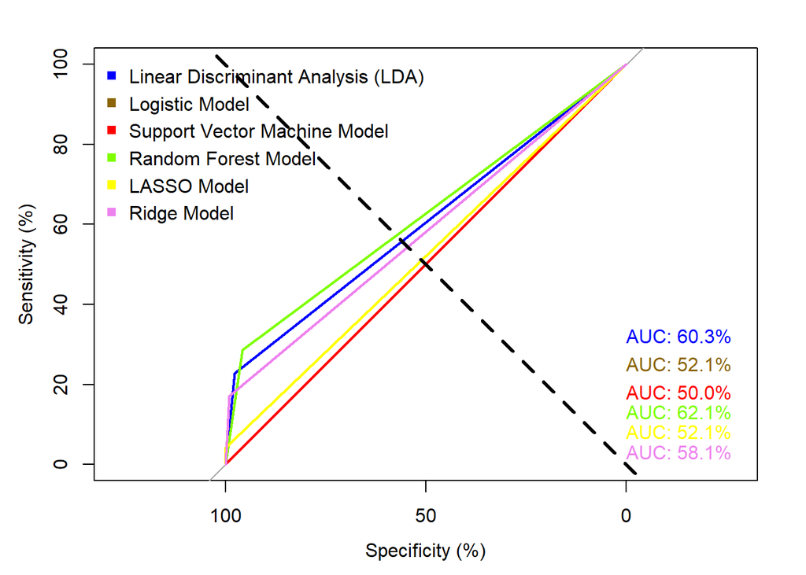

```r
plot(test_roc_lda,    print.auc = TRUE,  col='blue',percent=TRUE, print.auc.y = 34, print.auc.x = 0)
plot(test_roc_logistic, add = TRUE, col='darkgoldenrod4', print.auc = TRUE, print.auc.y = 27, print.auc.x = 0)
plot(test_roc_svm , add = TRUE, col='red', print.auc = TRUE, print.auc.y = 20, print.auc.x = 0)
plot(test_roc_rf , add = TRUE, col='chartreuse', print.auc = TRUE, print.auc.y = 15, print.auc.x = 0)
plot(test_roc_lasso , add = TRUE, col='yellow', print.auc = TRUE, print.auc.y = 10, print.auc.x = 0)
plot(test_roc_ridge , add = TRUE, col='violet', print.auc = TRUE, print.auc.y = 5, print.auc.x = 0)
abline(a=0, b=1, lty=2, lwd=3, col="black")
legend("topleft", legend = c("Linear Discriminant Analysis (LDA)","Logistic Model","Support Vector Machine Model","Random Forest Model","LASSO Model","Ridge Model") , pch = 15, bty = 'n', col = c("blue","darkgoldenrod4", "red","chartreuse","yellow","violet"))
```

# ML: Underweight

```r
set.seed(7)
# a) Linear Discriminant Analysis
fit.lda_wfa <- train( wfa_dummy~residence + age  + birth_order + gender + bwt  +num_child  +educ_mum +wealth_index+diarrhea +wt+region +source_water, data=train.wfa_dummy, method="lda", metric=metric, trControl=control,weight=train.wfa_dummy$Sample_wt,tuneLength=15)

# Support vector machine
set.seed(7)
fit.svm_wfa <- train( wfa_dummy~residence + age  + birth_order + gender + bwt  +num_child  +educ_mum +wealth_index  +diarrhea +wt+region +source_water, data=train.wfa_dummy, method="svmRadial", metric=metric, trControl=control,weight=train.wfa_dummy$Sample_wt,tuneLength=15)

# Logistic Model
set.seed(7)
fit.logistic_wfa <- train( wfa_dummy~residence + age  + birth_order + gender + bwt  +num_child  +educ_mum +wealth_index+diarrhea +wt+region +source_water, data=train.wfa_dummy, method="glmnet", metric=metric, trControl=control,weights=train.wfa_dummy$Sample_wt,family="binomial")

# Random forest Model
set.seed(7)
fit.rf_wfa <- train( wfa_dummy~residence + age  + birth_order + gender + bwt  +num_child  +educ_mum +wealth_index+diarrhea +wt+region +source_water, data=train.wfa_dummy, method="rf", metric=metric, trControl=control,weights=train.wfa_dummy$Sample_wt,tuneLength=15)

# LASSO Model
set.seed(7)
fit.lasso_wfa <- train( wfa_dummy~residence + age  + birth_order + gender + bwt  +num_child  +educ_mum +wealth_index+diarrhea +wt+region +source_water, data=train.wfa_dummy, method="glmnet", metric=metric, trControl=control,weights=train.wfa_dummy$Sample_wt,tuneGrid=expand.grid(alpha=1,lambda=lambda_vector))

# Get the optimal tuning parameter for the lasso
bestlambda_Lasso<-fit.lasso_wfa$bestTune$lambda
bestlambda_Lasso
```

```
## [1] 0
```

```r
# refit the lasso model with the best lambda
set.seed(7)
fit.lasso_wfa <- train( wfa_dummy~residence + age  + birth_order + gender + bwt  +num_child  +educ_mum +wealth_index+diarrhea +wt+region +source_water, data=train.wfa_dummy, method="glmnet", metric=metric, trControl=control,weights=train.wfa_dummy$Sample_wt,tuneGrid=expand.grid(alpha=1,lambda=bestlambda_Lasso))



# initial Ridge Regression with vector lambda
set.seed(7)
fit.ridge_wfa <- train( wfa_dummy~residence + age  + birth_order + gender + bwt  +num_child  +educ_mum +wealth_index+diarrhea +wt+region +source_water, data=train.wfa_dummy, method="glmnet", metric=metric, trControl=control,weights=train.wfa_dummy$Sample_wt,tuneGrid=expand.grid(alpha=0,lambda=lambda_vector))

# Get the optimal tunning parameter for the ridge
bestlambda_ridge<-fit.ridge_wfa$bestTune$lambda
bestlambda_ridge
```

```
## [1] 0
```

```r
# refit the ridge model with the best tuning parameters
set.seed(7)
fit.ridge_wfa <- train( wfa_dummy~residence + age  + birth_order + gender + bwt  +num_child  +educ_mum +wealth_index+diarrhea +wt+region +source_water, data=train.wfa_dummy, method="glmnet", metric=metric, trControl=control,weights=train.wfa_dummy$Sample_wt,tuneGrid=expand.grid(alpha=0,lambda=bestlambda_ridge))
```

```r
# summarize accuracy of wfa models
results <- resamples(list("Linear Discriminant Analysis" =fit.lda_wfa,"Logistic Model"=fit.logistic_wfa, "Support Vector Machine " =fit.svm_wfa,"Random Forest" =fit.rf_wfa,LASSO=fit.lasso_wfa,Ridge=fit.ridge_wfa))
summary(results)
```

```
##
## Call:
## summary.resamples(object = results)
##
## Models: Linear Discriminant Analysis, Logistic Model, Support Vector Machine , Random Forest, LASSO, Ridge
## Number of resamples: 5
##
## Accuracy
##                                   Min.   1st Qu.    Median      Mean   3rd Qu.
## Linear Discriminant Analysis 0.8986175 0.9124424 0.9178082 0.9163524 0.9220183
## Logistic Model               0.9078341 0.9216590 0.9223744 0.9209481 0.9262673
## Support Vector Machine       0.8986175 0.9124424 0.9124424 0.9135790 0.9220183
## Random Forest                0.9315068 0.9357798 0.9400922 0.9485725 0.9631336
## LASSO                        0.8990826 0.9078341 0.9124424 0.9135917 0.9216590
## Ridge                        0.8986175 0.9032258 0.9041096 0.9062479 0.9124424
##                                   Max. NA's
## Linear Discriminant Analysis 0.9308756    0
## Logistic Model               0.9266055    0
## Support Vector Machine       0.9223744    0
## Random Forest                0.9723502    0
## LASSO                        0.9269406    0
## Ridge                        0.9128440    0
##
## Kappa
##                                   Min.   1st Qu.    Median      Mean   3rd Qu.
## Linear Discriminant Analysis 0.1211340 0.2157124 0.3660341 0.3006490 0.3808887
## Logistic Model               0.3647541 0.3807286 0.4176443 0.4227292 0.4339500
## Support Vector Machine       0.2214612 0.3462819 0.3462819 0.3487958 0.3839153
## Random Forest                0.5368673 0.5771682 0.6165557 0.6637643 0.7695167
## LASSO                        0.3355500 0.4493783 0.4882711 0.4751155 0.5421373
## Ridge                        0.1211340 0.1331558 0.1921658 0.1853977 0.2157124
##                                   Max. NA's
## Linear Discriminant Analysis 0.4194757    0
## Logistic Model               0.5165692    0
## Support Vector Machine       0.4460389    0
## Random Forest                0.8187135    0
## LASSO                        0.5602410    0
## Ridge                        0.2648207    0
```

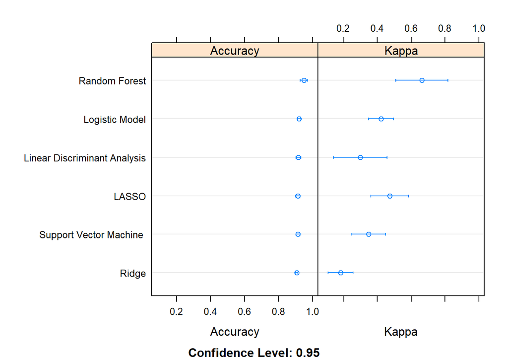

```r
dotplot(results)
```

```r
# summarize Best wfa Model
print(fit.rf_wfa)
```

```
## Random Forest
##
## 1088 samples
##   12 predictor
##    2 classes: '0', '1'
##
## No pre-processing
## Resampling: Cross-Validated (5 fold)
## Summary of sample sizes: 871, 870, 871, 871, 869
## Resampling results across tuning parameters:
##
##   mtry  Accuracy   Kappa
##    2    0.9025781  0.00000000
##    3    0.9044214  0.03313609
##    5    0.9108309  0.17525786
##    6    0.9145049  0.22596492
##    8    0.9246473  0.38237757
##   10    0.9292346  0.45865713
##   11    0.9310863  0.47941894
##   13    0.9366162  0.54985100
##   15    0.9384595  0.57028197
##   16    0.9375379  0.57156965
##   18    0.9467334  0.64215959
##   20    0.9485725  0.66261434
##   21    0.9485725  0.66376427
##   23    0.9458244  0.64567959
##   25    0.9476593  0.66214518
##
## Accuracy was used to select the optimal model using the largest value.
## The final value used for the model was mtry = 21.
```

## Confusion matrix

```r
# estimate skill of all wfa models  on the validation dataset
predictions <- predict(fit.lda_wfa, test.wfa_dummy)
confusionMatrix(predictions, test.wfa_dummy$ wfa_dummy,positive="1")
```

```
## Confusion Matrix and Statistics
##
##           Reference
## Prediction   0   1
##          0 418  37
##          1   2   8
##
##                Accuracy : 0.9161
##                  95% CI : (0.8871, 0.9397)
##     No Information Rate : 0.9032
##     P-Value [Acc > NIR] : 0.1956
##
##                   Kappa : 0.265
##
##  Mcnemar's Test P-Value : 5.199e-08
##
##             Sensitivity : 0.17778
##             Specificity : 0.99524
##          Pos Pred Value : 0.80000
##          Neg Pred Value : 0.91868
##              Prevalence : 0.09677
##          Detection Rate : 0.01720
##    Detection Prevalence : 0.02151
##       Balanced Accuracy : 0.58651
##
##        'Positive' Class : 1
##
```

```r
predictions <- predict(fit.logistic_wfa, test.wfa_dummy)
confusionMatrix(predictions, test.wfa_dummy$ wfa_dummy,positive="1")
```

```
## Confusion Matrix and Statistics
##
##           Reference
## Prediction   0   1
##          0 412  31
##          1   8  14
##
##                Accuracy : 0.9161
##                  95% CI : (0.8871, 0.9397)
##     No Information Rate : 0.9032
##     P-Value [Acc > NIR] : 0.195569
##
##                   Kappa : 0.3784
##
##  Mcnemar's Test P-Value : 0.000427
##
##             Sensitivity : 0.31111
##             Specificity : 0.98095
##          Pos Pred Value : 0.63636
##          Neg Pred Value : 0.93002
##              Prevalence : 0.09677
##          Detection Rate : 0.03011
##    Detection Prevalence : 0.04731
##       Balanced Accuracy : 0.64603
##
##        'Positive' Class : 1
##
```

```r
predictions <- predict(fit.svm_wfa, test.wfa_dummy)
confusionMatrix(predictions, test.wfa_dummy$ wfa_dummy,positive="1")
```

```
## Confusion Matrix and Statistics
##
##           Reference
## Prediction   0   1
##          0 413  32
##          1   7  13
##
##                Accuracy : 0.9161
##                  95% CI : (0.8871, 0.9397)
##     No Information Rate : 0.9032
##     P-Value [Acc > NIR] : 0.1955690
##
##                   Kappa : 0.362
##
##  Mcnemar's Test P-Value : 0.0001215
##
##             Sensitivity : 0.28889
##             Specificity : 0.98333
##          Pos Pred Value : 0.65000
##          Neg Pred Value : 0.92809
##              Prevalence : 0.09677
##          Detection Rate : 0.02796
##    Detection Prevalence : 0.04301
##       Balanced Accuracy : 0.63611
##
##        'Positive' Class : 1
##
```

```r
predictions <- predict(fit.rf_wfa, test.wfa_dummy)
confusionMatrix(predictions, test.wfa_dummy$ wfa_dummy,positive="1")
```

```
## Confusion Matrix and Statistics
##
##           Reference
## Prediction   0   1
##          0 417  20
##          1   3  25
##
##                Accuracy : 0.9505
##                  95% CI : (0.9267, 0.9684)
##     No Information Rate : 0.9032
##     P-Value [Acc > NIR] : 0.0001277
##
##                   Kappa : 0.6597
##
##  Mcnemar's Test P-Value : 0.0008492
##
##             Sensitivity : 0.55556
##             Specificity : 0.99286
##          Pos Pred Value : 0.89286
##          Neg Pred Value : 0.95423
##              Prevalence : 0.09677
##          Detection Rate : 0.05376
##    Detection Prevalence : 0.06022
##       Balanced Accuracy : 0.77421
##
##        'Positive' Class : 1
##
```

```r
predictions <- predict(fit.lasso_wfa, test.wfa_dummy)
confusionMatrix(predictions, test.wfa_dummy$ wfa_dummy,positive="1")
```

```
## Confusion Matrix and Statistics
##
##           Reference
## Prediction   0   1
##          0 410  16
##          1  10  29
##
##                Accuracy : 0.9441
##                  95% CI : (0.9191, 0.9632)
##     No Information Rate : 0.9032
##     P-Value [Acc > NIR] : 0.0009766
##
##                   Kappa : 0.6599
##
##  Mcnemar's Test P-Value : 0.3267996
##
##             Sensitivity : 0.64444
##             Specificity : 0.97619
##          Pos Pred Value : 0.74359
##          Neg Pred Value : 0.96244
##              Prevalence : 0.09677
##          Detection Rate : 0.06237
##    Detection Prevalence : 0.08387
##       Balanced Accuracy : 0.81032
##
##        'Positive' Class : 1
##
```

```r
predictions <- predict(fit.ridge_wfa, test.wfa_dummy)
confusionMatrix(predictions, test.wfa_dummy$ wfa_dummy,positive="1")
```

```
## Confusion Matrix and Statistics
##
##           Reference
## Prediction   0   1
##          0 417  42
##          1   3   3
##
##                Accuracy : 0.9032
##                  95% CI : (0.8727, 0.9285)
##     No Information Rate : 0.9032
##     P-Value [Acc > NIR] : 0.5396
##
##                   Kappa : 0.0971
##
##  Mcnemar's Test P-Value : 1.473e-08
##
##             Sensitivity : 0.066667
##             Specificity : 0.992857
##          Pos Pred Value : 0.500000
##          Neg Pred Value : 0.908497
##              Prevalence : 0.096774
##          Detection Rate : 0.006452
##    Detection Prevalence : 0.012903
##       Balanced Accuracy : 0.529762
##
##        'Positive' Class : 1
##
```

## Variable of importance

```r
varImp(fit.lda_wfa)
```

```
## ROC curve variable importance
##
##              Importance
## wt              100.000
## bwt              65.458
## educ_mum         50.996
## wealth_index     32.896
## birth_order      30.145
## num_child        24.218
## age              19.366
## residence         7.319
## source_water      5.179
## diarrhea          3.877
## gender            3.524
## region            0.000
```

```r
varImp(fit.logistic_wfa)
```

```
## glmnet variable importance
##
##   only 20 most important variables shown (out of 25)
##
##                     Overall
## educ_mumHigher      100.000
## regionBrong-Ahafo    30.670
## genderFemale         29.623
## regionVolta          28.169
## diarrheaYes          26.025
## wealth_indexRicher   25.738
## bwt                  22.061
## regionUpper West     19.760
## wealth_indexRichest  17.646
## wealth_indexMiddle   15.264
## regionNothern        14.917
## regionCentral        12.606
## educ_mumSecondary    12.402
## regionGreater Accra   9.353
## age                   8.144
## num_child             8.120
## regionEastern         7.372
## wt                    4.870
## wealth_indexPoorer    4.487
## birth_order           4.449
```

```r
varImp(fit.svm_wfa)
```

```
## ROC curve variable importance
##
##              Importance
## wt              100.000
## bwt              65.458
## educ_mum         50.996
## wealth_index     32.896
## birth_order      30.145
## num_child        24.218
## age              19.366
## residence         7.319
## source_water      5.179
## diarrhea          3.877
## gender            3.524
## region            0.000
```

```r
varImp(fit.rf_wfa)
```

```
## rf variable importance
##
##   only 20 most important variables shown (out of 25)
##
##                         Overall
## age                    100.0000
## wt                      73.6594
## bwt                     21.9911
## birth_order             10.6161
## num_child                5.6942
## genderFemale             5.5329
## regionUpper East         2.9402
## wealth_indexPoorer       2.0712
## educ_mumPrimary          1.9150
## regionNothern            1.6190
## residenceRural           1.6093
## regionCentral            1.6025
## regionVolta              1.3985
## regionUpper West         1.3972
## diarrheaYes              1.3914
## educ_mumSecondary        1.2211
## source_waterUnimproved   1.1144
## regionBrong-Ahafo        0.9785
## wealth_indexMiddle       0.8622
## wealth_indexRicher       0.8079
```

```r
varImp(fit.lasso_wfa)
```

```
## glmnet variable importance
##
##   only 20 most important variables shown (out of 25)
##
##                     Overall
## educ_mumHigher      100.000
## genderFemale         29.863
## wealth_indexRicher   22.887
## diarrheaYes          22.020
## regionVolta          18.648
## regionBrong-Ahafo    17.540
## wealth_indexRichest  16.992
## regionUpper West     16.546
## wealth_indexMiddle   14.196
## regionNothern        12.934
## bwt                  11.652
## age                   9.020
## educ_mumSecondary     8.457
## regionGreater Accra   7.097
## regionCentral         6.245
## wealth_indexPoorer    5.805
## wt                    5.326
## educ_mumPrimary       4.442
## regionAshanti         4.386
## birth_order           3.036
```

```r
varImp(fit.ridge_wfa)
```

```
## glmnet variable importance
##
##   only 20 most important variables shown (out of 25)
##
##                        Overall
## educ_mumHigher         100.000
## regionBrong-Ahafo       50.926
## bwt                     41.633
## regionVolta             38.194
## diarrheaYes             28.312
## wealth_indexRicher      24.561
## regionEastern           23.856
## regionNothern           21.479
## regionCentral           20.873
## genderFemale            19.350
## wealth_indexMiddle      18.390
## regionUpper West        17.776
## num_child               17.431
## educ_mumSecondary       15.606
## wealth_indexRichest     11.481
## source_waterUnimproved  10.149
## regionAshanti            9.139
## regionUpper East         8.204
## birth_order              6.331
## age                      4.611
```

```r
varImp(fit.lda_wfa,scale=FALSE)
```

```
## ROC curve variable importance
##
##              Importance
## wt               0.7581
## bwt              0.6734
## educ_mum         0.6380
## wealth_index     0.5936
## birth_order      0.5869
## num_child        0.5724
## age              0.5605
## residence        0.5310
## source_water     0.5257
## diarrhea         0.5225
## gender           0.5217
## region           0.5130
```

```r
varImp(fit.logistic_wfa,scale=FALSE)
```

```
## glmnet variable importance
##
##   only 20 most important variables shown (out of 25)
##
##                     Overall
## educ_mumHigher       2.6398
## regionBrong-Ahafo    0.8155
## genderFemale         0.7879
## regionVolta          0.7497
## diarrheaYes          0.6933
## wealth_indexRicher   0.6857
## bwt                  0.5889
## regionUpper West     0.5284
## wealth_indexRichest  0.4728
## wealth_indexMiddle   0.4101
## regionNothern        0.4010
## regionCentral        0.3402
## educ_mumSecondary    0.3348
## regionGreater Accra  0.2546
## age                  0.2228
## num_child            0.2221
## regionEastern        0.2024
## wt                   0.1366
## wealth_indexPoorer   0.1265
## birth_order          0.1255
```

```r
varImp(fit.svm_wfa,scale=FALSE)
```

```
## ROC curve variable importance
##
##              Importance
## wt               0.7581
## bwt              0.6734
## educ_mum         0.6380
## wealth_index     0.5936
## birth_order      0.5869
## num_child        0.5724
## age              0.5605
## residence        0.5310
## source_water     0.5257
## diarrhea         0.5225
## gender           0.5217
## region           0.5130
```

```r
varImp(fit.rf_wfa,scale=FALSE)
```

```
## rf variable importance
##
##   only 20 most important variables shown (out of 25)
##
##                        Overall
## age                    76.7179
## wt                     56.5690
## bwt                    17.0460
## birth_order             8.3448
## num_child               4.5799
## genderFemale            4.4565
## regionUpper East        2.4733
## wealth_indexPoorer      1.8085
## educ_mumPrimary         1.6890
## regionNothern           1.4627
## residenceRural          1.4552
## regionCentral           1.4500
## regionVolta             1.2939
## regionUpper West        1.2930
## diarrheaYes             1.2885
## educ_mumSecondary       1.1583
## source_waterUnimproved  1.0766
## regionBrong-Ahafo       0.9727
## wealth_indexMiddle      0.8837
## wealth_indexRicher      0.8422
```

```r
varImp(fit.lasso_wfa,scale=FALSE)
```

```
## glmnet variable importance
##
##   only 20 most important variables shown (out of 25)
##
##                     Overall
## educ_mumHigher       5.5899
## genderFemale         1.6693
## wealth_indexRicher   1.2794
## diarrheaYes          1.2309
## regionVolta          1.0424
## regionBrong-Ahafo    0.9805
## wealth_indexRichest  0.9498
## regionUpper West     0.9249
## wealth_indexMiddle   0.7935
## regionNothern        0.7230
## bwt                  0.6513
## age                  0.5042
## educ_mumSecondary    0.4728
## regionGreater Accra  0.3967
## regionCentral        0.3491
## wealth_indexPoorer   0.3245
## wt                   0.2977
## educ_mumPrimary      0.2483
## regionAshanti        0.2452
## birth_order          0.1697
```

```r
varImp(fit.ridge_wfa,scale=FALSE)
```

```
## glmnet variable importance
##
##   only 20 most important variables shown (out of 25)
##
##                        Overall
## educ_mumHigher         1.61205
## regionBrong-Ahafo      0.82596
## bwt                    0.67711
## regionVolta            0.62200
## diarrheaYes            0.46372
## wealth_indexRicher     0.40363
## regionEastern          0.39234
## regionNothern          0.35426
## regionCentral          0.34455
## genderFemale           0.32015
## wealth_indexMiddle     0.30478
## regionUpper West       0.29495
## num_child              0.28942
## educ_mumSecondary      0.26019
## wealth_indexRichest    0.19411
## source_waterUnimproved 0.17278
## regionAshanti          0.15659
## regionUpper East       0.14163
## birth_order            0.11161
## age                    0.08407
```

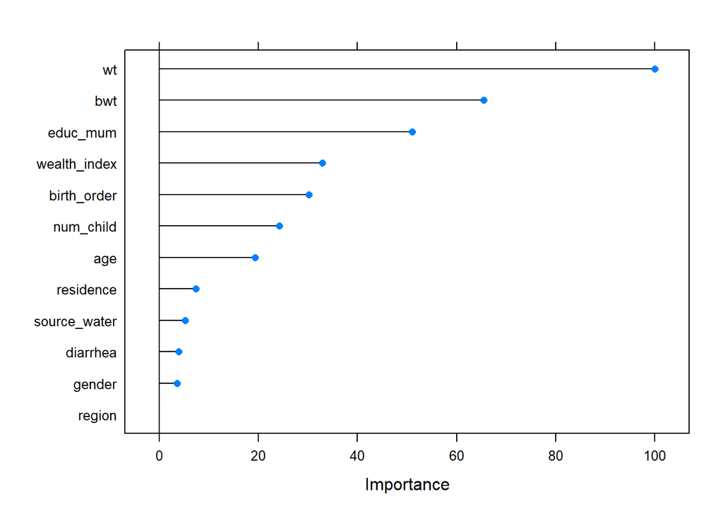

```r
plot(varImp(fit.lda_wfa))
```

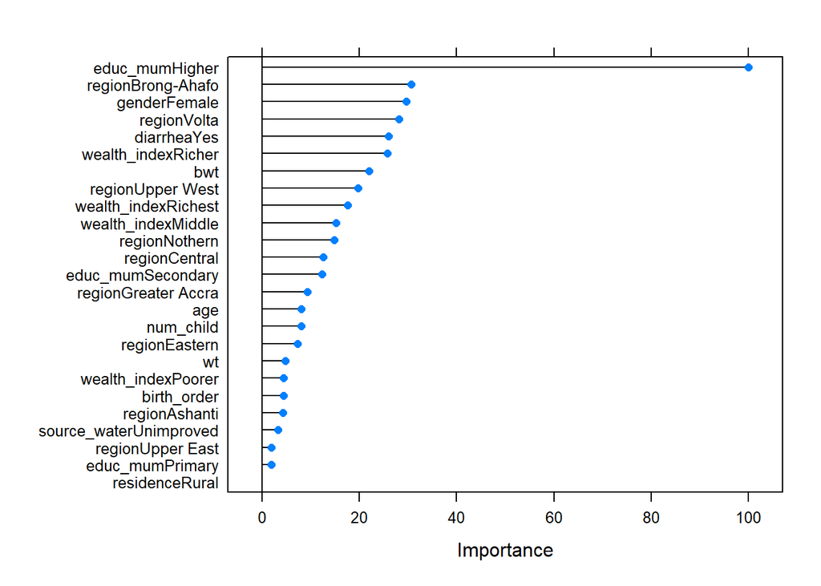

```r
plot(varImp(fit.logistic_wfa))
```

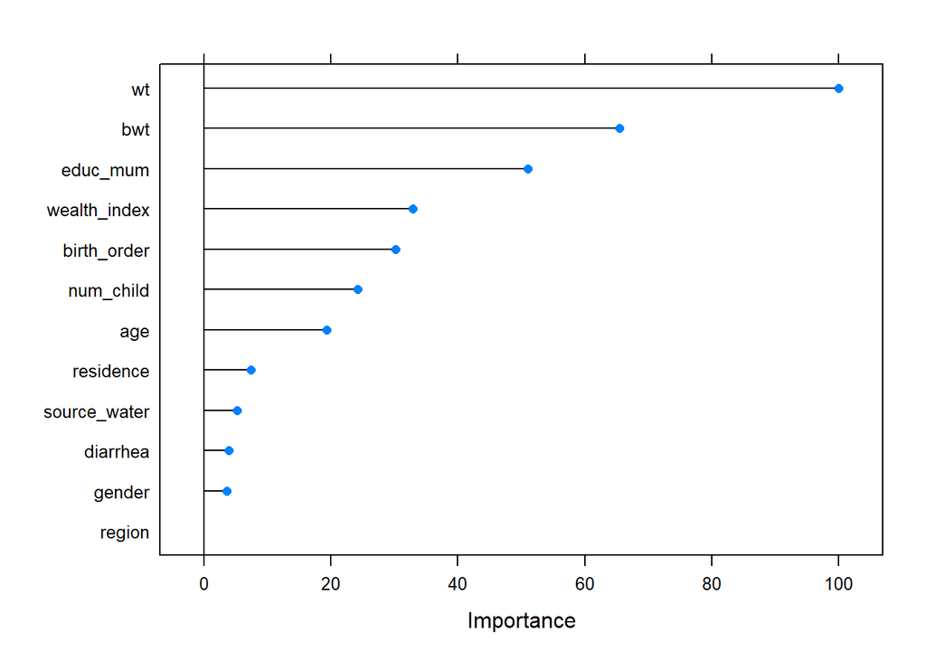

```r
plot(varImp(fit.svm_wfa))
```

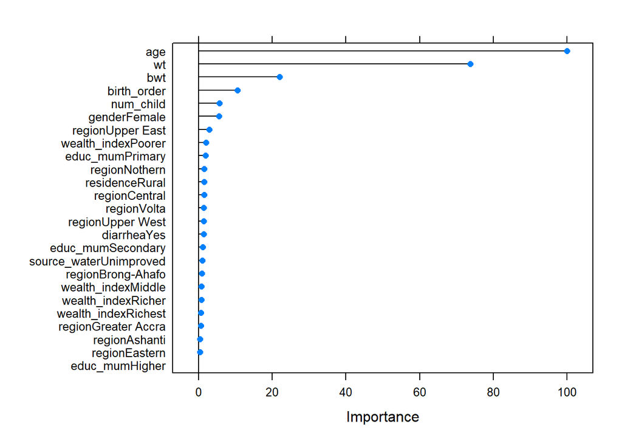

```r
plot(varImp(fit.rf_wfa))
```

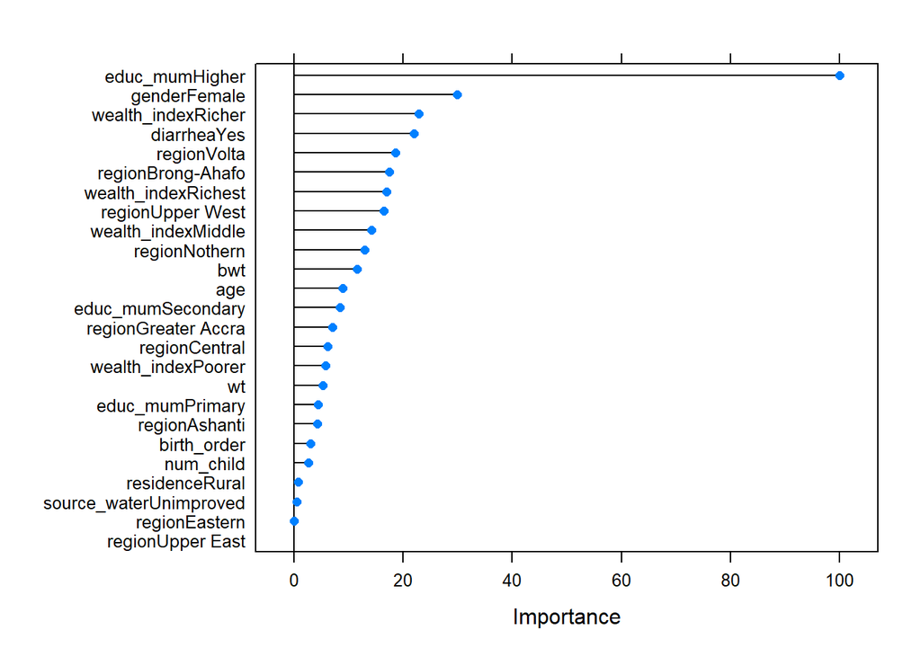

```r
plot(varImp(fit.lasso_wfa))
```

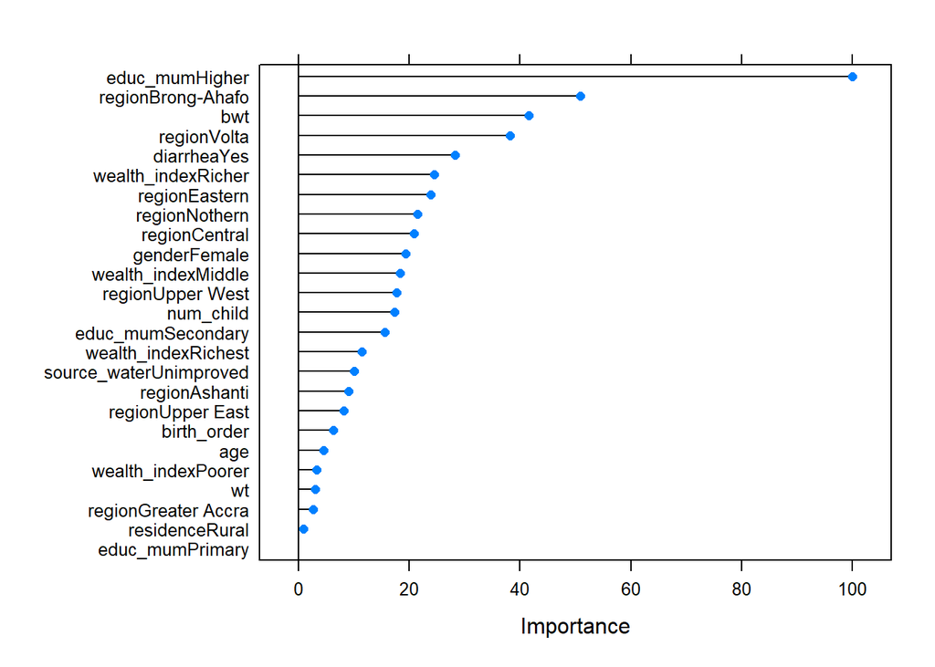

```r
plot(varImp(fit.ridge_wfa))
```